# Υπολογιστική Άλγεβρα

Σημειώσεις Μαθήματος

Συγγραφέας

Ζαφειράκης Ζαφειρακόπουλος

Δημοσιευμένο

3 Σεπτεμβρίου 2026

# 1 Εισαγωγή και Κίνητρα

## 1.1 Εισαγωγή

Αυτές οι σημειώσεις συνοδεύουν το μάθημα **439 Υπολογιστική Άλγεβρα** του τμήματος Μαθηματικών του ΕΚΠΑ. Κάθε ενότητα αντιστοιχεί σε ένα θέμα του μαθήματος και περιλαμβάνει:

- σύντομη παρουσίαση ορισμών και σχετικών θεωρημάτων,
- τον αντίστοιχο κώδικα στη Julia με χρήση του πακέτου [OSCAR](https://www.oscar-system.org/),
- παραδείγματα που εκτελούνται διαδραστικά και
- ασκήσεις.

Η ύλη ακολουθεί κυρίως τα βιβλία:

- Cox, Little, O’Shea, *Ideals, Varieties, and Algorithms* (Cox, Little, και O’Shea 2007),
- Bandini, Gianni, Sbarra, *Commutative Algebra through Exercises* (Bandini, Gianni, και Sbarra 2024),
- van der Waerden, *Modern Algebra*, Τόμος ΙΙ (Waerden 1950),
- Adams, Loustaunau, *An Introduction to Gröbner Bases* (Adams και Loustaunau 1994).

Σε κάθε ενότητα αναφέρεται συγκεκριμένα το κεφάλαιο/παράγραφος του βιβλίου από όπου προέρχεται ο ορισμός, το θεώρημα ή το παράδειγμα.

Σε κάθε κελί κώδικα φορτώνουμε το OSCAR ως εξής:

```julia
using Oscar
AbstractAlgebra.set_html_as_latex(true)
if isdefined(Main, :IJulia) && Main.IJulia.inited
    Base.showable(::MIME"text/latex", ::Union{AbstractAlgebra.NCRingElem,AbstractAlgebra.MatrixElem}) = false
end
```

[output not shown]

## 1.2 Γιατί Υπολογιστική Άλγεβρα;

**Σημείωση**

Η ενότητα αυτή είναι εισαγωγική/κινητοποιητική και δεν προέρχεται από τα τρία βασικά βιβλία του μαθήματος.

### 1.2.1 Ακριβής έναντι αριθμητικού υπολογισμού

Ο αλγόριθμος του Ευκλείδη είναι ίσως ο παλαιότερος αλγόριθμος που γνωρίζουμε:

```python
def gcd(a, b):
    while b:
        a, b = b, a % b
    return a
```

Το αποτέλεσμά του είναι **ακριβές** — το `gcd(a,b)` είναι *ακριβώς* ο μέγιστος κοινός διαιρέτης, όχι μια προσέγγισή του. Συγκρίνετε αυτό με τη μέθοδο του Αρχιμήδη για τον υπολογισμό του $\pi$: εγγράφοντας και περιγράφοντας κανονικά πολύγωνα $n$ πλευρών σε έναν κύκλο, παίρνουμε φράγματα $\text{κάτω} \le \pi \le \text{πάνω}$ που σφίγγουν όσο αυξάνουμε το $n$ — μια **αριθμητική** (αλλά ποτέ ακριβώς ακριβής) προσέγγιση, το αντικείμενο μελέτης της αριθμητικής ανάλυσης.

**Γιατί “συμβολικός” υπολογισμός;** Επειδή δεν είναι αριθμητικός — υπολογίζουμε πραγματικά με **σύμβολα**, όχι με προσεγγίσεις κινητής υποδιαστολής. Παράδειγμα: πώς υπολογίζουμε τη ρίζα του $x^2-3$;

- **(Α) Μέθοδος Newton:** αριθμητική, επαναληπτική, προσεγγιστική.
- **(Β) Τύπος** $\dfrac{-\beta \pm \sqrt{\beta^2-4\alpha\gamma}}{2\alpha}$: η **διακρίνουσα**. Ακριβής, κλειστή μορφή.

Σε αυτό το μάθημα ακολουθούμε την οδό (Β). Πρόκειται για ειδική περίπτωση για βαθμό $2$, και η διακρίνουσα με τη σειρά της είναι ειδική περίπτωση της **απαλοίφουσας** (§Απαλοίφουσα (Resultant)) — θα δούμε την απαλοίφουσα του Sylvester αργότερα στο μάθημα.

Μερικές φορές η λύση **μπορεί μόνο** να είναι συμβολική — π.χ. ποια είναι η παράγωγος του $ax^5-bx+c$ ως προς $x$; Η απάντηση, $5ax^4-b$, είναι η ίδια ένα πολυώνυμο (με σύμβολα $a,b,c$ ως παραμέτρους), όχι ένας αριθμός· δεν υπάρχει “αριθμητική” εναλλακτική.

**Λογισμικό.** Εμπορικά συστήματα υπολογιστικής άλγεβρας (CAS): Mathematica, Maple, Magma (και, για αριθμητικούς υπολογισμούς, Matlab). Η ελεύθερη/ανοιχτού κώδικα εναλλακτική είναι το [Sage](https://www.sagemath.org/), και σε αυτό το μάθημα χρησιμοποιούμε το [OSCAR](https://www.oscar-system.org/) (βασισμένο στη Julia, ενσωματώνει GAP, Singular, Polymake, Nemo/Hecke).

### 1.2.2 Τι είναι μια λύση; Η αναπαράσταση των αριθμών

**Ερώτηση.** Έχει ρίζα το $x^2-1$; Έχει ρίζα το $x^2-2$;

**Απάντηση.** Εξαρτάται **πού ψάχνουμε**: στο $\mathbb{C}$ πάντα έχει, στο $\mathbb{Z}$ το $x^2-2$ δεν έχει, στο $\mathbb{R}$ έχει.

Καλά, αλλά ποια ακριβώς είναι η λύση του $x^2-2$;

- “$1.4142$”; Όχι — αυτό είναι ένας **ρητός** αριθμός, όχι λύση της εξίσωσης.
- “$1.4142\ldots$”; Εννοιολογικά σωστό, αλλά δύσκολο να το αναπαραστήσουμε (η δεκαδική επέκταση δεν τερματίζει ούτε επαναλαμβάνεται).
- “$\sqrt{2}$”; Ακριβώς αυτό είναι η λύση! Και τι σημαίνει το σύμβολο $\sqrt{2}$; Ακριβώς αυτό που λέει: “η (δεύτερη) ρίζα του $x^2-2$”.

Γενικά, δεν είναι πάντα εύκολο να ορίσουμε τι είναι “μια λύση” ενός προβλήματος — η ίδια η περιγραφή του προβλήματος είναι ήδη μια περιγραφή της λύσης, αλλά όχι πάντα μια **ικανοποιητική** μία. Επιπλέον, αφού θέλουμε να χρησιμοποιήσουμε υπολογιστή, χρειαζόμαστε **πεπερασμένες αναπαραστάσεις**:
$$1.41421\ldots \quad \rightsquigarrow \quad \sqrt{2} \quad \rightsquigarrow \quad (2,\ x^2-2).$$

**Τι μπορούμε να αναπαραστήσουμε;**

- $\mathbb{Z}$ $\checkmark$ — τετριμμένα.
- $\mathbb{Q}$ $\checkmark$ — απλά ζεύγη ακεραίων $(p,q)$.
- $\mathbb{R}$ $\times$ — “πάρα πολλοί”.

Τι σημαίνει “πάρα πολλοί”; Προφανώς υπάρχουν πάρα πολλοί ακέραιοι — αλλά είναι **αριθμήσιμα** πολλοί: ποτέ δεν χρειαζόμαστε όλους ταυτόχρονα, και η ερώτηση είναι αν μπορούμε να αναπαραστήσουμε *οποιονδήποτε* από αυτούς — και η απάντηση είναι ναι (δοθείσης απεριόριστης μνήμης). Το “πάρα πολλοί” για το $\mathbb{R}$ είναι διαφορετικής φύσης: είναι **υπεραριθμήσιμα** πολλοί — υπάρχουν στοιχεία του $\mathbb{R}$ που δεν μπορούμε να αναπαραστήσουμε ακριβώς με **κανέναν** πεπερασμένο τρόπο (αφού υπάρχουν μόνο αριθμήσιμα πολλές πεπερασμένες περιγραφές συνολικά, όποια γλώσσα περιγραφής κι αν επιλέξουμε).

Ποιους πραγματικούς αριθμούς **μπορούμε** τελικά να αναπαραστήσουμε ακριβώς;

**ΣημείωσηΠαρατήρηση (Αναπαράσταση αλγεβρικών αριθμών)**

Έστω $p \in \mathbb{Z}[x]$ πολυώνυμο με ακέραιους συντελεστές. Τότε κάθε $\alpha \in \mathbb{R}$ με $p(\alpha)=0$ μπορεί να αναπαρασταθεί ως το ζεύγος $(i, p)$, εννοώντας “η $i$-οστή (πραγματική) ρίζα του $p$” — μια πεπερασμένη αναπαράσταση (χρειάζεται μόνο μια σύμβαση διάταξης, π.χ. αύξουσα, και έναν τρόπο να απομονώσουμε τη ρίζα σε ένα διάστημα — ακριβώς αυτό που θα κάνουμε στην §Απομόνωση πραγματικών ριζών).

Οι αριθμοί αυτού του τύπου λέγονται **αλγεβρικοί**. Συμβολίζουμε με $\mathbb{R}_{\mathrm{alg}}$ το σύνολο των πραγματικών αλγεβρικών αριθμών. Αυτό είναι το **μεγαλύτερο** σύνολο αριθμών με το οποίο μπορούμε να υπολογίζουμε αποτελεσματικά — αλγοριθμικά.

Μένει όμως ένα πρακτικό ερώτημα: **πώς υπολογίζουμε πραγματικά τις ρίζες ενός πολυωνύμου**, ώστε η αναπαράσταση $(i,p)$ να είναι κάτι παραπάνω από θεωρητική; Αυτό είναι ακριβώς το αντικείμενο της §Απομόνωση πραγματικών ριζών αργότερα στο μάθημα (κανόνας του Descartes, θεώρημα Budan, ακολουθίες Sturm).

### 1.2.3 Μοντελοποίηση προβλημάτων με πολυωνυμικά συστήματα

Πολλά προβλήματα από τη μηχανική και τις επιστήμες είναι **γραμμικά** προβλήματα (γραμμική άλγεβρα αρκεί). Λίγα απαιτούν ειδικές συναρτήσεις. Τα υπόλοιπα μοντελοποιούνται συχνά με **πολυωνυμικά συστήματα** — παραδείγματα: βιολογία (protein docking), ρομποτική, χημεία (μοριακή διαμόρφωση — π.χ. οι δίεδρες γωνίες ενός δακτυλίου κυκλοεξανίου ικανοποιούν πολυωνυμικούς περιορισμούς ανάλογους με του ρομποτικού βραχίονα παρακάτω), αυτόματη απόδειξη θεωρημάτων, στατιστική/μηχανική μάθηση, κοινωνικές επιστήμες, κρυπτογραφία, κ.ά.

Η ιδέα είναι να προσδιορίσουμε τις παραμέτρους του προβλήματος και “θέσεις-κράτησης” (placeholders) για τη λύση, και μετά να ορίσουμε πολυωνυμικές σχέσεις ανάμεσά τους. Ωραία, αλλά πώς τα **λύνουμε**; Οι **βάσεις Gröbner** — που εισήγαγε ο Buchberger το 1965 — δίνουν την απάντηση: όχι μόνο απέδειξε ύπαρξη, αλλά έδωσε **αλγόριθμο**. Οι βάσεις Gröbner ήταν αρχικά η απάντηση σε ένα κεντρικό πρόβλημα της καθαρής άλγεβρας — το **ideal membership** — αλλά η λύση αυτή έγινε στάνταρ εργαλείο και είναι εν τέλει πιο χρήσιμη στις εφαρμογές παρά στη θεωρία.

**Παράδειγμα: Ρομποτική.** Θεωρήστε ένα επίπεδο ρομποτικό βραχίονα με δύο τμήματα μήκους $a_1, a_2$, με γωνίες $\theta_1$ (στη βάση) και $\theta_2$ (στον αγκώνα). Η θέση του άκρου είναι
$$x_0 = a_1 \cos\theta_1 + a_2\cos(\theta_1+\theta_2), \qquad y_0 = a_1 \sin\theta_1 + a_2\sin(\theta_1+\theta_2).$$

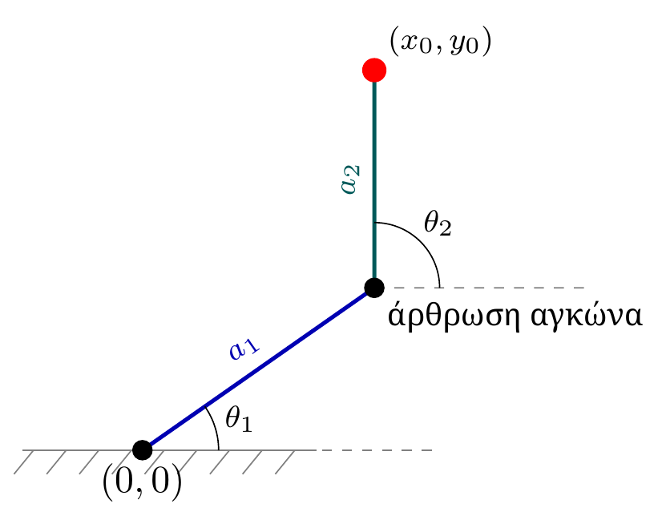

Ο επίπεδος ρομποτικός βραχίονας δύο τμημάτων: γωνίες $\theta_1,\theta_2$ και μήκη $a_1,a_2$.

**Πρόβλημα αντίστροφης κινηματικής (Inverse Kinematics):** δοθέντος ενός σημείου-στόχου $(x_0,y_0)$, βρείτε τις γωνίες $\theta_1,\theta_2$ ώστε ο βραχίονας να φτάσει εκεί. Το εμπόδιο είναι ότι το σύστημα εμπλέκει τριγωνομετρικές συναρτήσεις, όχι πολυώνυμα. Λύση: χρησιμοποιούμε τους τύπους αθροίσματος γωνιών
$$\cos(\theta_1+\theta_2) = \cos\theta_1\cos\theta_2 - \sin\theta_1\sin\theta_2, \qquad \sin(\theta_1+\theta_2) = \sin\theta_1\cos\theta_2+\cos\theta_1\sin\theta_2,$$
και θέτουμε $x_1=\cos\theta_1,\, y_1=\sin\theta_1,\, x_2=\cos\theta_2,\, y_2=\sin\theta_2$ (νέες μεταβλητές!), με τους επιπλέον περιορισμούς $x_1^2+y_1^2=1$, $x_2^2+y_2^2=1$ (αφού $(\cos,\sin)$ βρίσκονται πάντα στον μοναδιαίο κύκλο). Το σύστημα γίνεται **πολυωνυμικό**:
$$x_0 = a_1x_1 + a_2(x_1x_2-y_1y_2), \qquad y_0 = a_1y_1+a_2(x_1y_2+x_2y_1), \qquad x_1^2+y_1^2=1,\qquad x_2^2+y_2^2=1.$$

Ας λύσουμε ένα συγκεκριμένο στιγμιότυπο με το OSCAR (βραχίονας με $a_1=2,\, a_2=1$, στόχος $(x_0,y_0)=(2,1)$) — χρησιμοποιώντας ακριβώς την ίδια στρατηγική (βάση Gröbner ως προς `lex`, `real_solutions`) που θα μελετήσουμε συστηματικά αργότερα:

```julia
Rk, (x1k, y1k, x2k, y2k) = polynomial_ring(QQ, [:x1, :y1, :x2, :y2])
a1k, a2k = 2, 1
x0k, y0k = 2, 1
Sk = ideal(Rk, [
    a1k*x1k + a2k*(x1k*x2k - y1k*y2k) - x0k,
    a1k*y1k + a2k*(x1k*y2k + x2k*y1k) - y0k,
    x1k^2 + y1k^2 - 1,
    x2k^2 + y2k^2 - 1,
])
real_solutions(Sk)
```

```
(Vector{QQFieldElem}[[5153960755//8589934592, 6871947673//8589934592, 0, -1], [1, 0, 0, 1]], AlgebraicSolving.RationalParametrization([:x1, :y1, :x2, :y2], ZZRingElem[], x^2 - 1, 2*x, QQPolyRingElem[8//5*x + 2//5, 4//5*x - 4//5, 0]))
```

Κάθε λύση $(x_1,y_1,x_2,y_2)$ αντιστοιχεί σε μια διαμόρφωση του βραχίονα (“αγκώνας πάνω”/“αγκώνας κάτω”) που φτάνει στο $(2,1)$· ανακτούμε τις γωνίες με $\theta_i = \operatorname{atan2}(y_i,x_i)$. Δεν χρειάστηκε να ξέρουμε *τίποτα* για το πώς υπολογίστηκε αυτή η βάση Gröbner — και αυτό είναι ακριβώς το ζητούμενο: μια γενική μέθοδος που λύνει **οποιοδήποτε** πολυωνυμικό σύστημα, χωρίς εξειδικευμένο τρικ ανά πρόβλημα. Το πώς λειτουργεί είναι το αντικείμενο του υπόλοιπου μαθήματος.

**ΠροσοχήΣύνοψη**

- Ο συμβολικός υπολογισμός δίνει **ακριβή** αποτελέσματα, σε αντίθεση με τους αριθμητικούς (προσεγγιστικούς) υπολογισμούς.
- Δεν μπορούμε να αναπαραστήσουμε κάθε πραγματικό αριθμό ακριβώς σε υπολογιστή· το μεγαλύτερο σύνολο με το οποίο υπολογίζουμε αλγοριθμικά είναι οι πραγματικοί **αλγεβρικοί** αριθμοί $\mathbb{R}_{\mathrm{alg}}$, κάθε ένας αναπαριστάμενος πεπερασμένα ως ζεύγος (πολυώνυμο, δείκτης ρίζας).
- Πολλά προβλήματα μηχανικής/επιστημών μοντελοποιούνται ως πολυωνυμικά συστήματα (π.χ. αντίστροφη κινηματική ρομπότ) — οι **βάσεις Gröbner** θα είναι το κεντρικό μας εργαλείο επίλυσης σε όλο το μάθημα.

# 2 Βασικές Αλγεβρικές Δομές

## 2.1 Δακτύλιοι, Σώματα και Ακέραιες Περιοχές

Πριν ξεκινήσουμε τη μελέτη της υπολογιστικής άλγεβρας, θυμόμαστε συνοπτικά μερικές βασικές αλγεβρικές δομές, ακολουθώντας το (Bandini, Gianni, και Sbarra 2024, τ. 159, κεφ. 1.1).

**ΣημείωσηΟρισμός (Δακτύλιος)**

Ένας **δακτύλιος** $(R, +, \cdot)$ είναι ένα σύνολο $R$ εφοδιασμένο με δύο πράξεις τέτοιες ώστε:

1. $(R, +)$ είναι αβελιανή ομάδα, με ουδέτερο στοιχείο $0$,
2. η $\cdot$ είναι προσεταιριστική,
3. ισχύουν οι επιμεριστικοί νόμοι: $a(b+c) = ab + ac$ και $(a+b)c = ac + bc$ για κάθε $a,b,c \in R$.

Ο δακτύλιος λέγεται **αντιμεταθετικός** αν $ab = ba$ για κάθε $a, b \in R$, και λέγεται ότι έχει **μοναδιαίο στοιχείο** αν υπάρχει $1 \in R$ με $1 \cdot a = a \cdot 1 = a$ για κάθε $a \in R$.

**Σε όλες τις επόμενες ενότητες, εκτός αν δηλώνεται διαφορετικά, κάθε δακτύλιος θεωρείται αντιμεταθετικός με μοναδιαίο στοιχείο $1 \neq 0$** — αυτή είναι άλλωστε και η σύμβαση που ακολουθεί το OSCAR.

**ΣημείωσηΟρισμός (Σώμα)**

Ένα **σώμα** είναι ένας αντιμεταθετικός δακτύλιος $K$ με $1 \neq 0$, στον οποίο κάθε μη μηδενικό στοιχείο είναι αντιστρέψιμο: για κάθε $a \in K \setminus \{0\}$ υπάρχει $a^{-1} \in K$ με $a \, a^{-1} = 1$.

**ΣημείωσηΟρισμός (Διαιρέτης του μηδενός, Ακέραια Περιοχή)**

Έστω $R$ αντιμεταθετικός δακτύλιος. Ένα στοιχείο $a \in R$, $a \neq 0$, λέγεται **διαιρέτης του μηδενός** αν υπάρχει $b \in R$, $b \neq 0$, με $ab = 0$.

Ο $R$ λέγεται **ακέραια περιοχή** (integral domain) αν $1 \neq 0$ και δεν έχει διαιρέτες του μηδενός, δηλαδή:
$$ab = 0 \implies a = 0 \ \text{ή} \ b = 0.$$

**ΣημαντικόΘεώρημα**

1. Κάθε σώμα είναι ακέραια περιοχή.
2. Κάθε πεπερασμένη ακέραια περιοχή είναι σώμα.

**Παραδείγματα.** Ο $\mathbb{Z}$ είναι ακέραια περιοχή αλλά όχι σώμα (τα μόνα αντιστρέψιμα στοιχεία είναι τα $\pm 1$). Οι $\mathbb{Q}, \mathbb{R}, \mathbb{C}$ είναι σώματα. Ο δακτύλιος $\mathbb{Z}/n\mathbb{Z}$ είναι σώμα αν και μόνο αν ο $n$ είναι πρώτος· διαφορετικά έχει διαιρέτες του μηδενός.

Στο OSCAR, τα βασικά αυτά σύνολα αντιστοιχούν σε έτοιμους δακτυλίους/σώματα:

```julia
ZZ          # δακτύλιος των ακεραίων
```

```
Integer ring
```

```julia
QQ          # σώμα των ρητών
```

```
Rational field
```

```julia
F = GF(5)   # πεπερασμένο σώμα με 5 στοιχεία
inv(F(3))
```

$2$

**Παράδειγμα.** Ο $\mathbb{Z}/6\mathbb{Z}$ δεν είναι ακέραια περιοχή, αφού $2 \cdot 3 = 0$ ενώ $2, 3 \neq 0$:

```julia
R, f = residue_ring(ZZ, 6)
a, b = R(2), R(3)
a * b
```

$0$

ενώ για πρώτο modulo, π.χ. $\mathbb{Z}/7\mathbb{Z}$, παίρνουμε σώμα και κάθε μη μηδενικό στοιχείο είναι αντιστρέψιμο:

```julia
R7, f7 = residue_ring(ZZ, 7)
c = R7(3)
inv(c)
```

$5$

**ΣυμβουλήΆσκηση (Bandini, Gianni, και Sbarra 2024, Άσκ. 8.3)**

Έστω $A = \mathbb{Z}/n\mathbb{Z}$, $n \neq 0, \pm 1$.

1. Για $n = 24$, περιγράψτε τους διαιρέτες του μηδενός $D(A)$ και τα αντιστρέψιμα στοιχεία $A^*$.
2. Το ίδιο για $n = 17$.
3. Για ποιες τιμές του $n$ είναι το $A$ ακέραια περιοχή; Για ποιες είναι σώμα;

Σε πεπερασμένο αντιμεταθετικό δακτύλιο με μονάδα, κάθε μη μηδενικό στοιχείο είναι είτε αντιστρέψιμο είτε διαιρέτης του μηδενός (δεν υπάρχει τρίτη περίπτωση) — γι’ αυτό αρκεί να υπολογίσουμε το $A^*$ και το συμπλήρωμά του δίνει το $D(A)$:

```julia
R24, _ = residue_ring(ZZ, 24)
units24 = [a for a in 1:23 if is_unit(R24(a))]
zerodiv24 = [a for a in 1:23 if !is_unit(R24(a))]
units24, zerodiv24
```

```
([1, 5, 7, 11, 13, 17, 19, 23], [2, 3, 4, 6, 8, 9, 10, 12, 14, 15, 16, 18, 20, 21, 22])
```

Τα αντιστρέψιμα στοιχεία είναι ακριβώς τα $a$ με $\gcd(a,24)=1$, και όλα τα υπόλοιπα μη μηδενικά στοιχεία είναι διαιρέτες του μηδενός — το $\mathbb{Z}/24\mathbb{Z}$ δεν είναι ούτε ακέραια περιοχή ούτε σώμα. Για $n=17$ (πρώτος), κάθε μη μηδενικό στοιχείο είναι αντιστρέψιμο, οπότε $D(A) = \emptyset$ και το $A$ είναι σώμα:

```julia
is_prime(ZZ(17))   # το Z/17Z είναι σώμα ακριβώς όταν το 17 είναι πρώτος
```

```
true
```

Γενικά, το $\mathbb{Z}/n\mathbb{Z}$ είναι ακέραια περιοχή αν και μόνο αν είναι σώμα αν και μόνο αν ο $n$ είναι πρώτος (μια πεπερασμένη ακέραια περιοχή είναι πάντα σώμα, όπως είδαμε στο θεώρημα παραπάνω).

## 2.2 Ο δακτύλιος πολυωνύμων $K[x]$

Η κατασκευή του $K[x]$ ως δακτυλίου ακολουθιών, καθώς και το Θεώρημα της Ευκλείδειας διαίρεσης παρακάτω, ακολουθούν το (Cox, Little, και O’Shea 2007, κεφ. 1, §5).

**ΣημείωσηΟρισμός (Δακτύλιος πολυωνύμων μιας μεταβλητής)**

Έστω $K$ σώμα. Ο δακτύλιος πολυωνύμων $K[x]$ είναι το σύνολο των ακολουθιών $(a_0, a_1, a_2, \dots)$, $a_i \in K$, που είναι **τελικά μηδενικές** (δηλαδή $a_i = 0$ για κάθε $i$ μεγαλύτερο από κάποιο $d$), εφοδιασμένο με τις πράξεις

$$(a_i) + (b_i) = (a_i + b_i), \qquad (a_i) * (b_i) = (c_i), \ \text{όπου} \ c_i = \sum_{j=0}^{i} a_j b_{i-j}.$$

Ο πολλαπλασιασμός $*$ λέγεται **γινόμενο Cauchy** ή **συνέλιξη** (convolution). Γράφοντας $x = (0,1,0,0,\dots)$, η ακολουθία $(a_0, \dots, a_d, 0, 0, \dots)$ ταυτίζεται με το γνωστό πολυώνυμο $a_0 + a_1 x + \cdots + a_d x^d$.

Στο OSCAR:

```julia
R, x = polynomial_ring(QQ, :x)
f = 3x^3 - x^2 + 5x + 1
degree(f), leading_coefficient(f)
```

```
(3, 3)
```

**ΣημαντικόΘεώρημα (Ευκλείδεια διαίρεση στο $K[x]$)**

Έστω $f, g \in K[x]$ με $g \neq 0$. Τότε υπάρχουν **μοναδικά** $q, r \in K[x]$ ώστε
$$f = qg + r, \qquad r = 0 \ \text{ή} \ \deg(r) < \deg(g).$$

Το OSCAR υπολογίζει το πηλίκο και το υπόλοιπο με την `divrem`:

```julia
g = x^2 - 2
q, r = divrem(f, g)
q, r
```

```
(3*x - 1, 11*x - 1)
```

```julia
f == q * g + r
```

```
true
```

**ΣημείωσηΟρισμός (Ευκλείδεια Περιοχή) (Bandini, Gianni, και Sbarra 2024, τ. 159, κεφ. 1.6)**

Μια ακέραια περιοχή $R$ λέγεται **Ευκλείδεια περιοχή** αν υπάρχει συνάρτηση βαθμού $\delta: R \setminus \{0\} \to \mathbb{N}$ ώστε:

1. για κάθε $a, b \in R$ με $b \neq 0$ υπάρχουν $q, r \in R$ με $a = bq + r$, όπου $r = 0$ ή $\delta(r) < \delta(b)$,
2. $\delta(a) \le \delta(ab)$ για κάθε $a, b \in R \setminus \{0\}$.

Ο $\mathbb{Z}$ (με $\delta = |\cdot|$) και ο $K[x]$ (με $\delta = \deg$) είναι Ευκλείδειες περιοχές.

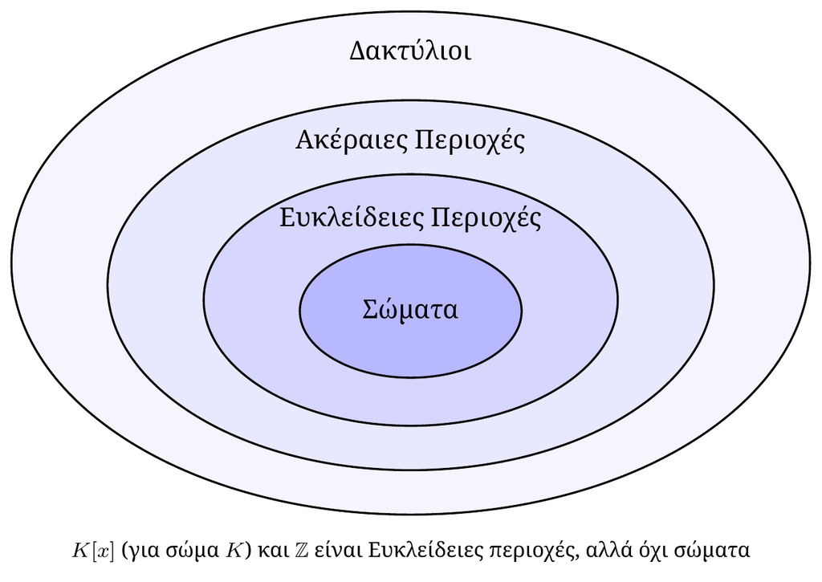

Η ιεραρχία των αλγεβρικών δομών που είδαμε: κάθε σώμα είναι Ευκλείδεια περιοχή, κάθε Ευκλείδεια περιοχή είναι ακέραια περιοχή, κάθε ακέραια περιοχή είναι δακτύλιος — αλλά όχι αντίστροφα.

**ΣυμβουλήΆσκηση (Cox, Little, και O’Shea 2007, κεφ. 1, §5, Άσκ. 8α)**

Υπολογίστε το $\gcd(f_1, f_2, f_3)$ όπου $f_1 = x^4+x^2+1$, $f_2 = x^4-x^2-2x-1$, $f_3 = x^3-1$.

Το $K[x]$ είναι Ευκλείδεια περιοχή, άρα ο $\gcd$ τριών (ή περισσότερων) πολυωνύμων υπολογίζεται εφαρμόζοντας τον Ευκλείδειο αλγόριθμο ανά ζεύγη: $\gcd(f_1,f_2,f_3) = \gcd(\gcd(f_1,f_2), f_3)$, αφού το $\gcd$ είναι προσεταιριστικό:

```julia
gcd(gcd(x^4 + x^2 + 1, x^4 - x^2 - 2x - 1), x^3 - 1)
```

$x^{2} + x + 1$

Ο κοινός παράγοντας $x^2+x+1$ είναι λοιπόν ο μέγιστος κοινός διαιρέτης και των τριών πολυωνύμων.

**ΠροσοχήΣύνοψη**

- Δακτύλιος, σώμα, ακέραια περιοχή, Ευκλείδεια περιοχή: η ιεραρχία δομών πάνω στην οποία χτίζεται όλο το μάθημα.
- Το $K[x]$ είναι Ευκλείδεια περιοχή (Ευκλείδεια διαίρεση, $\gcd$ μέσω του αλγορίθμου του Ευκλείδη) — η βάση για όλη τη μονομεταβλητή θεωρία που ακολουθεί.
- Σύμβαση του μαθήματος: κάθε δακτύλιος θεωρείται αντιμεταθετικός με μοναδιαίο στοιχείο $1 \neq 0$, όπως και στο OSCAR.

# 3 Παραγοντοποίηση Πολυωνύμων

## 3.1 Παραγοντοποίηση πολυωνύμων

**Σημείωση**

Η ενότητα αυτή δεν προέρχεται από τα τρία βασικά βιβλία του μαθήματος· βλ. (Gathen και Gerhard 2013, κεφ. 14–16) για πλήρη ανάπτυξη.

Κάθε Ευκλείδεια περιοχή είναι περιοχή μοναδικής παραγοντοποίησης (UFD) — άρα το $K[x]$ παραγοντοποιείται μοναδικά (έως τάξη και μονάδες) σε ανάγωγα πολυώνυμα. Αυτό όμως είναι υπαρξιακό: πώς υπολογίζουμε πραγματικά μια τέτοια παραγοντοποίηση;

### 3.1.1 Τετραγωνο-ελεύθερο μέρος

**ΣημείωσηΟρισμός (Τετραγωνο-ελεύθερο πολυώνυμο)**

Το $f \in K[x]$ λέγεται **τετραγωνο-ελεύθερο** (square-free) αν δεν έχει επαναλαμβανόμενους ανάγωγους παράγοντες, δηλαδή $f = c\prod_i p_i$ με $p_i$ ανά δύο μη συνεταιρικά ανάγωγα.

Αν $\operatorname{char}(K)=0$ (ή, γενικότερα, αν $\gcd(\deg p_i, \operatorname{char} K)=1$ για κάθε ανάγωγο παράγοντα), τότε $f$ τετραγωνο-ελεύθερο $\iff \gcd(f,f')=1$. Γενικότερα, το **τετραγωνο-ελεύθερο μέρος** $f/\gcd(f,f')$ έχει ακριβώς τις ίδιες ρίζες με το $f$, αλλά καθεμιά με πολλαπλότητα $1$ — ακριβώς αυτό που θα χρησιμοποιήσουμε αμέσως στην κατασκευή της ακολουθίας Sturm στην §Ακολουθίες Sturm:

```julia
Rf, xf = polynomial_ring(QQ, :x)
ff = (xf - 1)^3 * (xf + 2)^2 * (xf - 5)
divexact(ff, gcd(ff, derivative(ff)))   # (x-1)(x+2)(x-5), κάθε ρίζα μία φορά
```

$x^{3} - 4 x^{2} - 7 x + 10$

### 3.1.2 Παραγοντοποίηση πάνω από πεπερασμένα σώματα

Η παραγοντοποίηση πάνω από $\mathbb{F}_q$ είναι το θεμέλιο πάνω στο οποίο χτίζονται και οι αλγόριθμοι για το $\mathbb{Z}[x]/\mathbb{Q}[x]$ (μέσω αναγωγής $\bmod\, p$).

**ΣημαντικόΘεώρημα (Berlekamp, 1967) (Berlekamp 1967)**

Έστω $f \in \mathbb{F}_q[x]$ τετραγωνο-ελεύθερο, βαθμού $n$. Ο **υπόχωρος Berlekamp**
$$\mathcal{B} = \{ h \in \mathbb{F}_q[x]/\langle f \rangle : h^q \equiv h \pmod{f} \}$$
(τα σταθερά σημεία του ενδομορφισμού Frobenius $h \mapsto h^q$) είναι $\mathbb{F}_q$-διανυσματικός υπόχωρος διάστασης **ακριβώς ίσης** με το πλήθος των ανάγωγων παραγόντων του $f$. Επιπλέον, από μια βάση του $\mathcal{B}$ ανακτούμε την πλήρη παραγοντοποίηση υπολογίζοντας $\gcd(f, h-c)$ για $h \in \mathcal{B}$ και $c \in \mathbb{F}_q$.

Διαισθητικά: από το Κινέζικο Θεώρημα Υπολοίπων, $\mathbb{F}_q[x]/\langle f \rangle \cong \prod_i \mathbb{F}_q[x]/\langle p_i \rangle$ (ένας παράγοντας ανά ανάγωγο $p_i$), και σε κάθε παράγοντα ο Frobenius $h \mapsto h^q$ έχει ως σταθερά σημεία ακριβώς το υπόσωμα $\mathbb{F}_q$ — άρα ο συνολικός χώρος σταθερών σημείων έχει διάσταση ίση με το πλήθος των παραγόντων. Το υπολογιστικό κόστος είναι κυρίως γραμμική άλγεβρα (εύρεση πυρήνα του $Q - I$, όπου $Q$ ο πίνακας του Frobenius στη μονωνυμική βάση) — γρήγορο για μικρό $q$, αλλά χειροτερεύει καθώς το $q$ μεγαλώνει.

Για μεγάλα $q$ προτιμάται ο **πιθανοτικός** αλγόριθμος Cantor–Zassenhaus: πρώτα **διαχωρισμός κατά βαθμό** (distinct-degree factorization) — υπολογίζοντας $\gcd(x^{q^d}-x, f)$ παίρνουμε το γινόμενο όλων των ανάγωγων παραγόντων βαθμού $d$ — και μετά **διαχωρισμός ίσου βαθμού** (equal-degree splitting) μέσω τυχαίων στοιχείων, που σπάει το γινόμενο σε μεμονωμένους παράγοντες με αναμενόμενο πολυωνυμικό χρόνο (Cantor και Zassenhaus 1981).

```julia
Rp, xp = polynomial_ring(GF(7), :x)
factor(xp^6 - 1)
```

$\left(x + 1\right) \cdot \left(x + 2\right) \cdot \left(x + 3\right) \cdot \left(x + 4\right) \cdot \left(x + 5\right) \cdot \left(x + 6\right)$

### 3.1.3 Από τα πεπερασμένα σώματα στο $\mathbb{Z}[x]$: ανύψωση Hensel

Για να παραγοντοποιήσουμε $f \in \mathbb{Z}[x]$, μια φυσική στρατηγική είναι να παραγοντοποιήσουμε πρώτα $\bmod\, p$ (Berlekamp/Cantor–Zassenhaus) και μετά να “ανεβάσουμε” την παραγοντοποίηση σε $\bmod\, p^k$ για αρκετά μεγάλο $k$ ώστε να ανακτήσουμε τους ακέραιους συντελεστές.

**ΣημαντικόΘεώρημα (Ανύψωση Hensel)**

Αν $f \equiv g_0 h_0 \pmod p$ με $\gcd(g_0,h_0)=1 \pmod p$, τότε για κάθε $k\ge 1$ υπάρχουν (μοναδικά, έως αντιστρέψιμη σταθερά) $g_k, h_k$ με $f \equiv g_k h_k \pmod{p^k}$, $g_k \equiv g_0$, $h_k \equiv h_0 \pmod p$. Η ανύψωση από $\bmod\, p^k$ σε $\bmod\, p^{2k}$ γίνεται με μία εφαρμογή “τύπου Newton” — άρα ο αριθμός των βημάτων είναι λογαριθμικός ως προς το τελικό $k$.

Μένει ένα τελευταίο εμπόδιο: η παραγοντοποίηση $\bmod\, p^k$ μπορεί να έχει *περισσότερους* παράγοντες απ’ ό,τι η αληθινή παραγοντοποίηση στο $\mathbb{Z}[x]$ (δύο ανάγωγοι παράγοντες πάνω από $\mathbb{Z}$ μπορεί να συμπίπτουν $\bmod\, p$ σε γινόμενο περισσότερων $\bmod\,p$ παραγόντων) — οπότε χρειάζεται να δοκιμάσουμε **συνδυασμούς** υποσυνόλων των $\bmod\, p^k$ παραγόντων, κάτι εκθετικό στη χειρότερη περίπτωση (κλασικός αλγόριθμος Zassenhaus). Οι Lenstra, Lenstra και Lovász έλυσαν αυτό το πρόβλημα το 1982: χρησιμοποιώντας **αναγωγή βάσης πλέγματος** (lattice basis reduction — ο περίφημος αλγόριθμος **LLL**) βρίσκουν τον σωστό συνδυασμό σε πολυωνυμικό χρόνο, δίνοντας τον πρώτο αποδεδειγμένα πολυωνυμικού χρόνου αλγόριθμο παραγοντοποίησης για το $\mathbb{Q}[x]$ (Lenstra, Lenstra, και Lovász 1982).

```julia
Rz, xz = polynomial_ring(ZZ, :x)
factor(xz^4 - 10xz^2 + 1)   # ανάγωγο πάνω από Q, αλλά διασπάται mod κάθε πρώτο
```

$x^{4} - 10 x^{2} + 1$

**ΣυμβουλήΆσκηση**

Επαληθεύστε με το OSCAR ότι το $x^4-10x^2+1$ (πάνω από το $\mathbb{Q}$, ανάγωγο) διασπάται σε γινόμενο δύο τετραγωνικών παραγόντων modulo κάθε πρώτο $p$ (δοκιμάστε $p=2,3,5,7$) — ένα κλασικό παράδειγμα όπου *καμία* αναγωγή $\bmod\, p$ δεν “βλέπει” την πλήρη (ανάγωγη) εικόνα πάνω από το $\mathbb{Q}$, γι’ αυτό και χρειαζόμαστε ανύψωση Hensel σε αρκετά υψηλή δύναμη $p^k$ πριν τον συνδυαστικό έλεγχο.

**ΠροσοχήΣύνοψη**

- **Τετραγωνο-ελεύθερο μέρος** $f/\gcd(f,f')$: ίδιες ρίζες με το $f$, αλλά η καθεμιά με πολλαπλότητα $1$ — απαραίτητο εργαλείο για ό,τι ακολουθεί.
- Παραγοντοποίηση πάνω από πεπερασμένα σώματα: **Berlekamp** (γραμμική άλγεβρα, υπόχωρος σταθερών σημείων του Frobenius) και **Cantor–Zassenhaus** (πιθανοτικός, προτιμότερος για μεγάλο $q$).
- **Ανύψωση Hensel** + **LLL**: πώς περνάμε από παραγοντοποίηση $\bmod\,p$ σε παραγοντοποίηση πάνω από το $\mathbb{Q}$, σε αποδεδειγμένα πολυωνυμικό χρόνο.

# 4 Απομόνωση Πραγματικών Ριζών

## 4.1 Απομόνωση πραγματικών ριζών

**Σημείωση**

Η ενότητα αυτή καλύπτει κλασικά αποτελέσματα πραγματικής άλγεβρας (Cauchy, Landau, Descartes, Budan, Sturm) που **δεν προέρχονται από τα τρία βασικά βιβλία του μαθήματος** — δεν τα καλύπτει κανένα από αυτά, οπότε δεν δίνεται συγκεκριμένη παραπομπή σε αυτά.

### 4.1.1 Φράγματα ριζών

Έστω $f = x^d + c_{d-1}x^{d-1} + \cdots + c_1 x + c_0 \in \mathbb{R}[x]$ **μονικό**, και $a \in \mathbb{R}$ με $f(a) = 0$. Τα ακόλουθα “αφελή” (αλλά χρήσιμα) φράγματα δίνουν άνω φράγμα $|a| < C$:

- **Cauchy:** $|a| < 1 + \max_{0 \le i < d} |c_i|$
- **Zassenhaus:** $|a| \le 2 \max_{0 \le i < d} |c_i|^{1/(d-i)}$
- **Landau:** $|a| \le \left( c_0^2 + c_1^2 + \cdots + c_{d-1}^2 \right)^{1/2}$

```julia
Rx, xr = polynomial_ring(QQ, :x)

function cauchy_bound(f)
    f = divexact(f, leading_coefficient(f))     # κάνουμε το f μονικό
    cs = [coeff(f, i) for i in 0:degree(f)-1]
    return 1 + maximum(abs.(cs))
end

cauchy_bound(xr^3 - 2xr - 5)
```

$6$

### 4.1.2 Κανόνας προσήμων του Descartes

**ΣημαντικόΘεώρημα (Descartes)**

Ο αριθμός των θετικών πραγματικών ριζών ενός $f \in \mathbb{R}[x]$ (με πολλαπλότητα) είναι ίσος με τον αριθμό εναλλαγών προσήμου στην ακολουθία των (μη μηδενικών) συντελεστών του $f$, ή διαφέρει από αυτόν κατά άρτιο αριθμό. Οι αρνητικές ρίζες μετριούνται εφαρμόζοντας το ίδιο στο $f(-x)$.

```julia
function sign_changes(f)
    cs = filter(!iszero, [coeff(f, i) for i in 0:degree(f)])
    return count(i -> sign(cs[i]) != sign(cs[i+1]), 1:length(cs)-1)
end

g = -5xr^11 - 9xr^10 + 8xr^5 + 5xr^3 - 3xr^2 - xr + 1
sign_changes(g)   # άρα 3 ή 1 θετικές πραγματικές ρίζες
```

```
3
```

### 4.1.3 Θεώρημα Budan και η μέθοδος διχοτόμησης

**ΣημαντικόΘεώρημα (Budan)**

Έστω $f = \sum a_i x^i$ και $V_f = \delta(a_0,\dots,a_d)$ ο αριθμός εναλλαγών προσήμου των συντελεστών του $f$. Για $\rho < r$ πραγματικούς, θέτουμε $V_\rho = V_{f(x+\rho)}$, $V_r = V_{f(x+r)}$. Τότε:

1. $V_\rho \ge V_r$,
2. το πλήθος των πραγματικών ριζών στο $(\rho, r)$ (με πολλαπλότητα) είναι $\le V_\rho - V_r$,
3. αν το πλήθος αυτό είναι γνησίως μικρότερο του $V_\rho - V_r$, τότε η διαφορά είναι άρτιος αριθμός.

Το θεώρημα Budan δίνει έναν αλγόριθμο **διχοτόμησης** (bisection) για την απομόνωση των πραγματικών ριζών σε ένα φράγμα $[-C, C]$ (π.χ. $C$ = φράγμα Cauchy): ξεκινώντας από τη λίστα διαστημάτων $L = [(-C,C)]$, σε κάθε βήμα εξάγουμε ένα $(\rho, r)$ και:

- αν $V_\rho - V_r = 0$: δεν υπάρχει ρίζα, το πετάμε,
- αν $V_\rho - V_r = 1$: το $(\rho, r)$ **απομονώνει** μία ρίζα,
- αν $V_\rho - V_r > 1$: το χωρίζουμε σε $\left[\rho, \tfrac{\rho+r}{2}\right], \left[\tfrac{\rho+r}{2}, r\right]$ και τα ξαναβάζουμε στη λίστα.

**Προειδοποίηση**

Το φράγμα $V_\rho - V_r$ του Budan μπορεί να **υπερεκτιμά** το πλήθος ριζών κατά άρτιο αριθμό — π.χ. αν σε ένα διάστημα υπάρχουν 0 ρίζες, ο αλγόριθμος μπορεί να μη σταματήσει το χωρισμό αμέσως. Παρακάτω, οι **ακολουθίες Sturm** δίνουν τον **ακριβή** αριθμό ριζών, λύνοντας το πρόβλημα αυτό.

**Φράγμα διαχωρισμού (separation bound).** Δύο διαφορετικές ρίζες $\gamma_i \neq \gamma_j$ ενός $f$ απέχουν τουλάχιστον
$$\operatorname{sep}(f) = \min_{i \neq j} |\gamma_i - \gamma_j| \ \ge\ 2^{-d \cdot e}, \qquad e = \max_{0 \le i \le d} \log|a_i|,$$
κάτι που μας λέει πόσο “βαθιά” μπορεί να χρειαστεί να διχοτομήσουμε για να διαχωρίσουμε δύο κοντινές ρίζες.

### 4.1.4 Ακολουθίες Sturm

**ΣημείωσηΟρισμός (Ακολουθία Sturm)**

Έστω $f \in \mathbb{R}[x]$ και $[a,b] \subseteq \mathbb{R} \cup \{-\infty,\infty\}$. Μια ακολουθία πολυωνύμων $(f_1,\dots,f_k)$ είναι **ακολουθία Sturm** για το $f$ στο $[a,b]$ αν $f_1 = f$ και:

1. $f_1(a) f_1(b) \neq 0$,
2. $f_k(c) \neq 0$ για κάθε $c \in [a,b]$,
3. αν $f_j(c) = 0$ για κάποιο $c \in [a,b]$ και $2 \le j \le k-1$, τότε $f_{j-1}(c) f_{j+1}(c) < 0$,
4. αν $f_1(c) = 0$ για κάποιο $c \in [a,b]$, τότε το $f_1 f_2$ αλλάζει πρόσημο από $-$ σε $+$ καθώς περνάμε από το $c$.

Αν το $f$ είναι χωρίς πολλαπλές ρίζες (square-free), μια ακολουθία Sturm κατασκευάζεται με $f_1 = f$, $f_2 = f'$, και $f_i = -\operatorname{rem}(f_{i-2}, f_{i-1})$ (ακολουθία υπολοίπων με αλλαγή προσήμου, όπως ο Ευκλείδειος αλγόριθμος).

**ΣημαντικόΘεώρημα (Sturm)**

Αν $(f_1,\dots,f_k)$ είναι ακολουθία Sturm για το $f$ στο $[a,b]$, τότε το πλήθος **διακριτών** πραγματικών ριζών του $f_1$ στο $[a,b]$ είναι **ακριβώς** $V(a) - V(b)$, όπου $V(c)$ ο αριθμός εναλλαγών προσήμου στην $(f_1(c), \dots, f_k(c))$.

```julia
function sturm_sequence(f)
    f1 = divexact(f, gcd(f, derivative(f)))   # square-free μέρος
    seq = [f1, derivative(f1)]
    while !iszero(seq[end])
        push!(seq, -mod(seq[end-1], seq[end]))
    end
    pop!(seq)
    return seq
end

sign_at(p, a::Union{Int,Rational,QQFieldElem}) = sign(evaluate(p, QQ(a)))
function sign_at(p, a::AbstractFloat)   # a = ±Inf
    s = sign(leading_coefficient(p))
    return a > 0 ? s : s * (iseven(degree(p)) ? 1 : -1)
end

num_sign_changes(vals) = (v = filter(!iszero, vals); count(i -> v[i]*v[i+1] < 0, 1:length(v)-1))

function sturm_root_count(f, a, b)
    seq = sturm_sequence(f)
    return num_sign_changes([sign_at(p, a) for p in seq]) - num_sign_changes([sign_at(p, b) for p in seq])
end

sturm_root_count(xr^2 - 2, 0, 2)          # μία ρίζα (το √2) στο [0,2]
```

```
1
```

```julia
sturm_root_count(xr^2 - 2, -Inf, Inf)     # συνολικά 2 πραγματικές ρίζες
```

```
2
```

**Απομόνωση όλων των ριζών.** Ο ίδιος αλγόριθμος διχοτόμησης όπως με το Budan, αλλά χρησιμοποιώντας τον *ακριβή* μετρητή ριζών του Sturm, απομονώνει κάθε πραγματική ρίζα σε ξεχωριστό διάστημα:

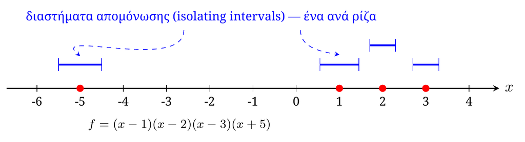

Απομόνωση των τεσσάρων πραγματικών ριζών του $f=(x-1)(x-2)(x-3)(x+5)$ σε ξένα μεταξύ τους διαστήματα.

```julia
function isolate_real_roots(f)
    seq = sturm_sequence(f)
    C = cauchy_bound(divexact(f, leading_coefficient(f)))
    stack = [(-C, C)]
    isolated = Tuple{QQFieldElem,QQFieldElem}[]
    while !isempty(stack)
        (a, b) = pop!(stack)
        v = num_sign_changes([sign_at(p, a) for p in seq]) - num_sign_changes([sign_at(p, b) for p in seq])
        if v == 1
            push!(isolated, (a, b))
        elseif v > 1
            m = (a + b)//2
            push!(stack, (a, m), (m, b))
        end
    end
    return sort(isolated, by = first)
end

isolate_real_roots((xr - 1) * (xr - 2) * (xr - 3) * (xr + 5))
```

```
4-element Vector{Tuple{QQFieldElem, QQFieldElem}}:
 (-50, 0)
 (0, 25//16)
 (25//16, 75//32)
 (75//32, 25//8)
```

### 4.1.5 Απομόνωση ριζών με συνεχή κλάσματα

**Σημείωση**

Η υποενότητα αυτή ακολουθεί το (Τσιγαρίδας 2006, κεφ. 3.6).

Η υποδιαίρεση δεν είναι ο μόνος τρόπος να απομονώσουμε τις ρίζες. Ο αλγόριθμος **cf** (continued fractions), που ανάγεται στον Vincent (1836) και βελτιώθηκε από τους Uspensky και Akritas, δουλεύει σε “χώρο συνεχών κλασμάτων” αντί να διχοτομεί κυριολεκτικά ένα διάστημα.

**ΣημείωσηΥπενθύμιση (Συνεχή κλάσματα)**

Ένα απλό συνεχές κλάσμα $[a_0;a_1,a_2,\dots]$ ορίζει μια ακολουθία **αναγωγημάτων** (convergents) $P_n/Q_n$ μέσω
$$P_{-1}{=}1,\ P_0{=}a_0,\ P_{n+1}{=}a_{n+1}P_n{+}P_{n-1}, \qquad Q_{-1}{=}0,\ Q_0{=}1,\ Q_{n+1}{=}a_{n+1}Q_n{+}Q_{n-1}.$$

**ΣημαντικόΘεώρημα (Vincent, 1836)**

Έστω $A \in \mathbb{Z}[X]$ τετραγωνο-ελεύθερο, βαθμού $d$, με φράγμα διαχωρισμού $\sigma$. Υπάρχει $n$ (φραγμένο συναρτήσει $d,\sigma$) τέτοιο ώστε, για **οποιαδήποτε** ακολουθία θετικών ακεραίων $a_0,\dots,a_n$, ο μετασχηματισμός Möbius
$$X \;\longmapsto\; [a_0;a_1,\dots,a_n,X] = \frac{P_nX+P_{n-1}}{Q_nX+Q_{n-1}}$$
μετατρέπει το $A$ σε πολυώνυμο με **το πολύ μία** εναλλαγή προσήμου.

**Ο αλγόριθμος.** Διατηρούμε έναν μετασχηματισμό Möbius $M(X)=\dfrac{pX+q}{rX+s}$ (αρχικά ταυτοτικό, $p{=}s{=}1,q{=}r{=}0$) και το μετασχηματισμένο πολυώνυμο $\hat A = A\circ M$ (ο αριθμητής του $A\circ M$, χωρίς παρονομαστές), το οποίο έχει τόσες θετικές ρίζες όσες έχει το $A$ στην εικόνα του $(0,\infty)$ μέσω του $M$. Σε κάθε βήμα, μετράμε τις εναλλαγές προσήμου $V$ του $\hat A$:

- $V=0$: καμία ρίζα σε αυτόν τον κλάδο — σταματάμε.
- $V=1$: **ακριβώς μία** ρίζα (Vincent) — το διάστημα απομόνωσης έχει άκρα $M(0)=q/s$ και $M(\infty)=p/r$ (δύο διαδοχικά αναγωγήματα του συνεχούς κλάσματος της ρίζας).
- $V\ge 2$: διακλαδιζόμαστε σε δύο υπο-προβλήματα, αναζητώντας ρίζες στο $(1,\infty)$ (μετασχηματισμός $X\mapsto X+1$) και στο $(0,1)$ (μετασχηματισμός $X\mapsto 1/(1+X)$), συνθέτοντας κάθε φορά το $M$ ανάλογα.

Το Θεώρημα του Vincent εγγυάται ότι αυτή η αναδρομή τερματίζει πάντα. Υλοποιούμε την ιδέα (μόνο για τις θετικές ρίζες — τις αρνητικές τις βρίσκουμε εφαρμόζοντας το ίδιο στο $f(-x)$):

```julia
function reverse_poly(f)
    Rf = parent(f); xg = gen(Rf); d = degree(f)
    return sum(coeff(f, d - i) * xg^i for i in 0:d)
end

function cf_isolate_positive(f, C)
    xg = gen(parent(f))
    intervals = Tuple{QQFieldElem,QQFieldElem}[]
    stack = [(f, QQ(1), QQ(0), QQ(0), QQ(1))]   # (πολυώνυμο, p, q, r, s), M(X) = (pX+q)/(rX+s)
    while !isempty(stack)
        (g, p, q, r, s) = pop!(stack)
        v = sign_changes(g)
        if v == 0
            continue
        elseif v == 1
            a = q // s
            b = iszero(r) ? C : p // r
            push!(intervals, minmax(a, b))
        else
            g1 = g(xg + 1)                               # X ↦ X+1, ψάχνουμε στο (1,∞)
            push!(stack, (g1, p, p + q, r, r + s))
            g2 = reverse_poly(g)(xg + 1)                 # X ↦ 1/(1+X), ψάχνουμε στο (0,1)
            push!(stack, (g2, q, p + q, s, r + s))
        end
    end
    return intervals
end

function cf_isolate_real_roots(f)
    C = cauchy_bound(divexact(f, leading_coefficient(f)))
    xg = gen(parent(f))
    pos = cf_isolate_positive(f, C)
    neg = [(-b, -a) for (a, b) in cf_isolate_positive(f(-xg), C)]
    return sort(vcat(pos, neg), by = first)
end

cf_isolate_real_roots((xr - 1) * (xr - 2) * (xr - 3) * (xr + 5))
```

```
2-element Vector{Tuple{QQFieldElem, QQFieldElem}}:
 (-50, 0)
 (2, 50)
```

**ΣυμβουλήΆσκηση**

Τροποποιήστε τον `cf_isolate_positive` ώστε να μετράει και να επιστρέφει το βάθος του δυαδικού δέντρου αναδρομής (πλήθος κλήσεων). Συγκρίνετέ το με το πλήθος των διαστημάτων που εξετάζει το `isolate_real_roots` για το ίδιο πολυώνυμο.

### 4.1.6 Φράγμα διαχωρισμού και πολυπλοκότητα της υποδιαίρεσης

Το `isolate_real_roots` παραπάνω κάνει ουσιαστικά **δυαδική αναζήτηση** (υποδιαίρεση διαστήματος), ξεκινώντας από το φράγμα Cauchy $[-C,C]$: σε κάθε βήμα κόβει το τρέχον διάστημα στη μέση, μέχρι κάθε υποδιάστημα να περιέχει ακριβώς μία ρίζα (μετρημένη ακριβώς μέσω Sturm). Αυτό τερματίζει πάντα (αφού το $f$ έχει πεπερασμένες ρίζες), αλλά **πόσο βαθιά** χρειάζεται να φτάσει το δέντρο υποδιαίρεσης;

Η απάντηση εξαρτάται από το πόσο **κοντά** μπορεί να είναι δύο διαφορετικές ρίζες — όσο πιο κοντά, τόσο περισσότερες διαιρέσεις στη μέση χρειάζονται για να τις χωρίσουμε.

**ΣημείωσηΟρισμός (Φράγμα διαχωρισμού)**

Για $f \in \mathbb{R}[x]$ με πραγματικές ρίζες $\gamma_1,\dots,\gamma_r$ (χωρίς πολλαπλότητες), ορίζουμε
$$\operatorname{sep}(f) = \min_{i \neq j} |\gamma_i - \gamma_j|.$$

**ΣημαντικόΘεώρημα (Mignotte)**

Για $f = x^d + a_{d-1}x^{d-1}+\cdots+a_0 \in \mathbb{Z}[x]$ μονικό, τετραγωνο-ελεύθερο,
$$\operatorname{sep}(f) \;\ge\; \sqrt{\dfrac{8}{d^{d+2}}} \cdot \dfrac{1}{\left(1+\max_{0\le i < d}|a_i|\right)^{d}},$$
και αυτό είναι **βέλτιστο** — ο Mignotte έδωσε μια οικογένεια πολυωνύμων που πετυχαίνει αυτό ακριβώς το φράγμα.

Το **αντίστροφο** φράγμα Cauchy δίνει επίσης ένα **κάτω** φράγμα στο μέγεθος οποιασδήποτε ρίζας: αν $\alpha \neq 0$ ρίζα, $|\alpha| > \dfrac{|a_0|}{1+\max_{1\le i<d}|a_i|}$.

Το bitsize (πλήθος bits) που χρειάζεται για να αναπαραστήσουμε το φράγμα διαχωρισμού είναι
$$L = \log(\operatorname{sep}(f)) \in O\!\left(d \log\left(\max_{0\le i<d}|a_i|\right)\right),$$
και αυτό ακριβώς φράσσει το **βάθος** του δέντρου υποδιαίρεσης παραπάνω (κάθε επίπεδο υποδιπλασιάζει το μήκος του διαστήματος, οπότε χρειαζόμαστε $O(L)$ επίπεδα ώστε το διάστημα να γίνει μικρότερο από $\operatorname{sep}(f)$ — άρα να μη χωράει πάνω από μία ρίζα). Αυτό δίνει ένα αποδεδειγμένο, πεπερασμένο φράγμα στην πολυπλοκότητα της απομόνωσης ριζών — ένα ακόμα παράδειγμα του θέματος που θα ξαναδούμε στην §Πολυπλοκότητα υπολογισμού βάσεων Gröbner: τα “αφελή” άνω φράγματα (εδώ, διπλασιασμός βάθους ανά bit εισόδου) είναι συχνά πολύ πιο ήπια απ’ ό,τι θα φοβόμασταν a priori.

# 5 Απαλοίφουσα και Εφαρμογές

## 5.1 Απαλοίφουσα (Resultant)

Βλ. (Bandini, Gianni, και Sbarra 2024, τ. 159, κεφ. 3.2) (βλ. επίσης (Cox, Little, και O’Shea 2007, κεφ. 3, §5–6)· για την κλασική θεωρία απαλοιφής βλ. και (Waerden 1950, τ. 2, κεφ. XI)).

**Κίνητρο.** Το τριώνυμο $f = ax^2+bx+c$ έχει διπλή ρίζα ακριβώς όταν τα $f, f'$ έχουν κοινή ρίζα, δηλαδή όταν η διακρίνουσα $D = b^2-4ac$ μηδενίζεται. Η **απαλοίφουσα** γενικεύει αυτή την ιδέα σε οποιοδήποτε ζεύγος πολυωνύμων.

**ΣημείωσηΟρισμός (Πίνακας Sylvester, Απαλοίφουσα)**

Έστω $f = \sum_{i=0}^{d_1} a_i x^i$, $g = \sum_{i=0}^{d_2} b_i x^i \in K[x]$. Ο **πίνακας Sylvester** $S_{f,g}$ είναι ο $(d_1+d_2)\times(d_1+d_2)$ πίνακας με $d_2$ γραμμές ολισθημένων συντελεστών του $f$ και $d_1$ γραμμές ολισθημένων συντελεστών του $g$:
$$S_{f,g} \;=\;
\begin{pmatrix}
a_{d_1} & a_{d_1-1} & \cdots & a_1 & a_0 & & & \\
& a_{d_1} & a_{d_1-1} & \cdots & a_1 & a_0 & & \\
& & \ddots & & & & \ddots & \\
& & & a_{d_1} & a_{d_1-1} & \cdots & a_1 & a_0 \\
b_{d_2} & b_{d_2-1} & \cdots & b_1 & b_0 & & & \\
& b_{d_2} & b_{d_2-1} & \cdots & b_1 & b_0 & & \\
& & \ddots & & & & \ddots & \\
& & & b_{d_2} & b_{d_2-1} & \cdots & b_1 & b_0
\end{pmatrix}.$$
Οι πρώτες $d_2$ γραμμές είναι διαδοχικές ολισθήσεις (κατά μία θέση) της ακολουθίας συντελεστών $(a_{d_1},\dots,a_0)$ του $f$· οι επόμενες $d_1$ γραμμές είναι διαδοχικές ολισθήσεις της $(b_{d_2},\dots,b_0)$ του $g$ — ένας πίνακας **block-Toeplitz** (κάθε γραμμή είναι η προηγούμενη ολισθημένη κατά ένα). Η **απαλοίφουσα** (resultant) είναι
$$\operatorname{Res}_x(f,g) = \det(S_{f,g}).$$

**ΣημαντικόΘεώρημα**

$\operatorname{Res}_x(f,g) = 0 \iff$ τα $f, g$ έχουν κοινό παράγοντα (ισοδύναμα, κοινή ρίζα σε αλγεβρικά κλειστό σώμα, εκτός αν μηδενίζονται και οι δύο μεγιστοβάθμιοι συντελεστές).

**Απόδειξη (σκιαγράφηση).** Ο πίνακας $S_{f,g}$ παριστάνει, ως προς τις μονωνυμικές βάσεις, τη γραμμική απεικόνιση
$$(A,B) \longmapsto Af + Bg, \qquad \deg A < d_2, \ \deg B < d_1,$$
από τον χώρο ζευγών $(A,B)$ (διάστασης $d_1+d_2$) στον χώρο των πολυωνύμων βαθμού $<d_1+d_2$ (επίσης διάστασης $d_1+d_2$). Το $\operatorname{Res}_x(f,g) = \det(S_{f,g})$ μηδενίζεται ακριβώς όταν αυτή η απεικόνιση έχει μη τετριμμένο πυρήνα, δηλαδή όταν υπάρχουν $A, B$ όχι και τα δύο μηδέν, με $\deg A < d_2$, $\deg B < d_1$, ώστε $Af = -Bg$. Αν $\gcd(f,g)=1$, τότε $g \mid A$, άτοπο αφού $\deg A < d_2 = \deg g$ (εκτός αν $A=0$, οπότε και $B=0$)· άρα $\operatorname{Res}_x(f,g) \neq 0$. Αντίστροφα, αν $h = \gcd(f,g)$ έχει βαθμό $\ge 1$, τότε $A = g/h$, $B=-f/h$ δίνει μη τετριμμένη λύση. $\blacksquare$

**Ιδιότητες.** (1) $\operatorname{Res}_x(f,g) \in \mathbb{Z}[a_0,\dots,a_{d_1},b_0,\dots,b_{d_2}]$ (πολυώνυμο με ακέραιους συντελεστές στους συντελεστές των $f,g$)· (2) γράφοντας $f = a_{d_1}\prod_i (x-\xi_i)$, $g = b_{d_2}\prod_j(x-\eta_j)$,
$$\operatorname{Res}_x(f,g) = a_{d_1}^{d_2} \prod_i g(\xi_i) = (-1)^{d_1 d_2} b_{d_2}^{d_1} \prod_j f(\eta_j) = a_{d_1}^{d_2} b_{d_2}^{d_1} \prod_{i,j} (\xi_i - \eta_j)$$
(τύπος Poisson — προκύπτει αναπτύσσοντας το $\prod_i g(\xi_i)$ και χρησιμοποιώντας ότι το $\operatorname{Res}_x(f,g)/a_{d_1}^{d_2}$, ως συνάρτηση των ριζών $\eta_j$ του $g$, είναι συμμετρικό πολυώνυμο μηδενιζόμενο όταν κάποιο $\eta_j = \xi_i$)· (3) $\operatorname{Res}_x(f,g) = (-1)^{d_1 d_2}\operatorname{Res}_x(g,f)$· (4) $\operatorname{Res}_x(fg,h) = \operatorname{Res}_x(f,h)\operatorname{Res}_x(g,h)$.

```julia
Rres, xres = polynomial_ring(QQ, :x)
f = 2xres^2 + 3xres - 1
g = 2xres - 5
sylvester_matrix(f, g)
```

$\begin{array}{ccc} 2 & 3 & -1 \\ 2 & -5 & 0 \\ 0 & 2 & -5 \end{array}$

```julia
det(sylvester_matrix(f, g)) == resultant(f, g)
```

```
true
```

Επαληθεύουμε αριθμητικά τον τύπο Poisson με μιγαδικές ρίζες:

```julia
Rc, xcpx = polynomial_ring(AcbField(64), :x)
fc, gc = 2xcpx^2 + 3xcpx - 1, 3xcpx^3 - xcpx + 4
ξ, η = roots(fc), roots(gc)
ac, bc = leading_coefficient(fc), leading_coefficient(gc)
resultant(fc, gc), ac^degree(gc) * bc^degree(fc) * prod(xi - yj for xi in ξ for yj in η)
```

```
([-338.000000000000000 +/- 1.04e-16], [-338.00000 +/- 5.95e-6] + [+/- 5.63e-6]*im)
```

**Διακρίνουσα.** Για $f = ax^2+bx+c$, $\operatorname{Res}_x(f,f') = -a \cdot \operatorname{disc}(f)$:

```julia
Rd, (ad, bd, cd) = polynomial_ring(QQ, [:a, :b, :c])
Rdx, xd = polynomial_ring(Rd, :x)
fd = ad*xd^2 + bd*xd + cd
resultant(fd, derivative(fd)) == -ad * discriminant(fd)
```

```
true
```

### 5.1.1 Αριθμητική με αλγεβρικούς αριθμούς μέσω απαλοίφουσας

**Σημείωση**

Η υποενότητα αυτή είναι κίνητρο/παράδειγμα με βάση (Τσιγαρίδας 2006, κεφ. 4) — δεν αναπτύσσεται εκεί ως ολοκληρωμένο θεώρημα, αλλά επισημαίνεται ρητά ως φυσική επέκταση των εργαλείων του κεφαλαίου, με ανοιχτό ερώτημα την πολυπλοκότητά της.

Θυμηθείτε τη §Παρατήρηση (Αναπαράσταση αλγεβρικών αριθμών): κάθε πραγματικός αλγεβρικός αριθμός αναπαρίσταται πεπερασμένα ως ζεύγος (πολυώνυμο, δείκτης ρίζας). Αν $\alpha$ είναι ρίζα του $f$ και $\beta$ ρίζα του $g$, πώς βρίσκουμε ένα πολυώνυμο που έχει ως ρίζα το $\alpha+\beta$ (ή το $\alpha\beta$), ώστε το άθροισμα/γινόμενο να είναι κι αυτό ένας πεπερασμένα αναπαραστάσιμος αλγεβρικός αριθμός; Η απάντηση είναι, για ακόμη μια φορά, η απαλοίφουσα.

**ΣημαντικόΠρόταση (Άθροισμα, γινόμενο μέσω απαλοίφουσας)**

Έστω $f(\alpha)=0$, $g(\beta)=0$. Τότε:

- το $\alpha+\beta$ είναι ρίζα του $\operatorname{Res}_x\bigl(f(x),\, g(z-x)\bigr) \in K[z]$·
- το $\alpha\beta$ είναι ρίζα του $\operatorname{Res}_x\bigl(f(x),\, x^{\deg g}\, g(z/x)\bigr) \in K[z]$.

Ο λόγος: το $\operatorname{Res}_x(f(x),h(x,z))$ μηδενίζεται στο $z=z_0$ ακριβώς όταν τα $f(x)=0$, $h(x,z_0)=0$ έχουν **κοινή** ρίζα $x$ — δηλαδή, στην πρώτη περίπτωση, ακριβώς όταν $z_0 = x+y$ για κάποια ρίζα $x$ του $f$ και $y=z_0-x$ ρίζα του $g$.

**Προειδοποίηση**

Η απαλοίφουσα μπορεί να μηδενίζεται και σε **άλλους** συνδυασμούς ριζών (π.χ. $\xi_i+\eta_j$ για *όλα* τα ζεύγη ριζών, όχι μόνο το $(\alpha,\beta)$ που μας ενδιαφέρει) — άρα δίνει πολυώνυμο που έχει το $\alpha+\beta$ ως ρίζα, όχι απαραίτητα το **ελάχιστο** πολυώνυμό του. Στην πράξη διακρίνουμε ποιος ανάγωγος παράγοντας αντιστοιχεί στο $\alpha+\beta$ μέσω απομόνωσης ριζών (§Απομόνωση πραγματικών ριζών).

**Παράδειγμα.** Το $\sqrt2+\sqrt3$ είναι ρίζα του $x^4-10x^2+1$ — ακριβώς το πολυώνυμο που είδαμε στην §Παραγοντοποίηση πολυωνύμων ως ανάγωγο πάνω από το $\mathbb{Q}$, αλλά διασπώμενο modulo κάθε πρώτο!

Δουλεύουμε στο $(K[z])[x]$ — το $z$ ζει στον δακτύλιο συντελεστών, το $x$ είναι η μεταβλητή προς απαλοιφή (ίδιο σχήμα με τη διακρίνουσα παραπάνω):

```julia
Rz, zn = polynomial_ring(QQ, :z)
Rzx, xn = polynomial_ring(Rz, :x)

fn, gn = xn^2 - 2, xn^2 - 3
hsum = resultant(fn, gn(zn - xn))   # g(z - x), απαλείφει το x
```

$z^{4} - 10 z^{2} + 1$

```julia
factor(hsum)
```

$z^{4} - 10 z^{2} + 1$

Για το γινόμενο, γράφουμε $x^{\deg g}g(z/x)$ ως πολυώνυμο (χωρίς πηλίκα) απευθείας από τους συντελεστές του $g$:

```julia
homog_recip(g, z) = sum(coeff(g, i) * z^i * gen(parent(g))^(degree(g) - i) for i in 0:degree(g))

f2, g2 = xn^2 - 2, xn - 3   # ρίζες √2 και 3
hprod = resultant(f2, homog_recip(g2, zn))
factor(hprod)   # (√2)(3) = 3√2, ρίζα του x²-18
```

$z^{2} - 18$

Η ίδια ιδέα γενικεύεται σε διαφορά και πηλίκο. Μια πλήρης θεωρία υπολογισμού με αλγεβρικούς αριθμούς — αναπαράσταση, σύγκριση, πρόσημο, και η πολυπλοκότητα των τεσσάρων πράξεων — αναπτύσσεται στο (Τσιγαρίδας 2006, κεφ. 4–5).

### 5.1.2 Γενίκευση: η απαλοίφουσα $n$ μορφών σε $n$ μεταβλητές (Macaulay)

Ο Sylvester έδωσε την απαλοίφουσα δύο πολυωνύμων μιας μεταβλητής. Το 1902 ο **Macaulay** γενίκευσε την έννοια σε $n$ **ομογενείς** μορφές $f_1,\dots,f_n$ σε $n$ μεταβλητές $x_1,\dots,x_n$ (με αδιόριστους συντελεστές). Ακολουθούμε την κλασική, αλγεβρική κατασκευή του van der Waerden μέσω “μορφών αδράνειας” (Waerden 1950, τ. 2, κεφ. XII, §§81–83).

**ΣημείωσηΟρισμός (Μορφή αδράνειας, Απαλοίφουσα $n$ μορφών)**

Μια μορφή αδράνειας (inertia form) είναι ένα πολυώνυμο $T$ στους συντελεστές των $f_i$ και σε βοηθητικές μεταβλητές, τέτοιο ώστε $x_i^\lambda T \equiv 0 \pmod{f_1,\dots,f_n}$ για κάποιο $\lambda$, για κάθε $i$. Οι μορφές αδράνειας σχηματίζουν ιδεώδες $\mathfrak{T}$.

**ΣημαντικόΘεώρημα (van der Waerden, §82)**

Το $\mathfrak{T}$ είναι πρώτο κύριο ιδεώδες· ο (μοναδικός, έως σταθερά) γεννήτοράς του $R = \operatorname{Res}(f_1,\dots,f_n)$ λέγεται **απαλοίφουσα** των $f_1,\dots,f_n$, και ικανοποιεί:
$$R = 0 \iff \text{τα } f_1,\dots,f_n \text{ έχουν κοινή μη τετριμμένη λύση.}$$
Επιπλέον, $R$ είναι ομογενές βαθμού $L_i = \prod_{j \neq i} l_j$ στους συντελεστές του $f_i$ (όπου $l_j = \deg f_j$), και πολλαπλασιαστικό: αν $f_1 = g \cdot h$, τότε $\operatorname{Res}(f_1,\dots,f_n) = \operatorname{Res}(g,f_2,\dots,f_n) \cdot \operatorname{Res}(h,f_2,\dots,f_n)$.

Η απόδειξη ακολουθεί την ίδια λογική με το μονομεταβλητό θεώρημα: από την ταυτότητα $x_i^\lambda R \equiv \sum_j A_j f_j$ (ύπαρξη μορφής αδράνειας βαθμού μηδέν), αν όλα τα $f_j$ μηδενίζονται σε ένα σημείο με κάποιο $x_i \neq 0$, τότε $R = 0$· αντίστροφα, με απαλοιφή Kronecker (διαδοχική απαλοιφή μεταβλητών με απαλοίφουσες) δείχνεται ότι $R=0$ συνεπάγεται κοινή λύση.

**Μία υπολογίσιμη ειδική περίπτωση** (Waerden 1950, τ. 2, κεφ. XII, §82, Άσκ. 2)**.** Αν $f$ έχει βαθμό $l$ και $L_1,\dots,L_{n-1}$ είναι $n-1$ **γραμμικές** μορφές, τότε
$$\operatorname{Res}(f, L_1,\dots,L_{n-1}) = f(X_1,\dots,X_n),$$
όπου $(X_1,\dots,X_n)$ είναι το σημείο (ορισμένο έως σταθερά) που μηδενίζει όλα τα $L_i$ — δηλαδή το διάνυσμα των $(n-1)$-γραμμών υποοριζουσών του πίνακα των συντελεστών των $L_i$ (γενίκευση του εξωτερικού γινομένου). Το επαληθεύουμε για $n=3$:

```julia
Rm, (xm, ym, zm) = polynomial_ring(QQ, [:x, :y, :z])
L1, L2 = xm - ym, xm - zm                # δύο γραμμικές μορφές
X = (1, 1, 1)                             # κοινή ρίζα των L1, L2 (γενικευμένο εξωτερικό γινόμενο)

f_bad = xm^2 + ym^2 + zm^2                # f(X) = 3 ≠ 0
f_good = xm^2 + ym^2 - 2zm^2              # f(X) = 0

dim(ideal(Rm, [f_bad, L1, L2])), dim(ideal(Rm, [f_good, L1, L2]))
```

```
(0, 1)
```

Όταν $f(X) \neq 0$ (πρώτη περίπτωση), το ιδεώδες $\langle f,L_1,L_2\rangle$ έχει μόνο την τετριμμένη λύση $(0,0,0)$ (διάσταση $0$)· όταν $f(X)=0$ (δεύτερη περίπτωση), υπάρχει μια ολόκληρη κοινή ευθεία λύσεων (διάσταση $1$) — δηλαδή $\operatorname{Res}(f,L_1,L_2) = f(X) = 0$ ακριβώς όταν υπάρχει μη τετριμμένη κοινή λύση, όπως προβλέπει το θεώρημα.

**ΣυμβουλήΘεώρημα του Bezout (Waerden 1950, τ. 2, κεφ. XII, §83)**

Αν $n-1$ ομογενείς εξισώσεις σε $n$ μεταβλητές έχουν πεπερασμένο πλήθος λύσεων (ως ακτίνες), το άθροισμα των πολλαπλοτήτων τους ισούται με το γινόμενο των βαθμών των εξισώσεων. Για $n=3$: δύο αλγεβρικές καμπύλες βαθμού $d_1, d_2$ στο προβολικό επίπεδο τέμνονται σε ακριβώς $d_1 d_2$ σημεία (με πολλαπλότητα).

**Παρατήρηση (ρίζες στο άπειρο).** Ο βαθμός $\deg \operatorname{Res}_x(f,g) \le d_1 d_2$ (το φράγμα Bézout) μπορεί να **υπερεκτιμά** το πλήθος των πεπερασμένων κοινών ριζών του $f,g$ στο επίπεδο — μερικές από τις $d_1 d_2$ τομές “λείπουν” επειδή βρίσκονται **στο άπειρο** (ή έχουν πολλαπλότητα $>1$). Αυτό είναι φυσικό μόλις θυμηθούμε ότι το θεώρημα του Bezout αφορά **προβολικές** καμπύλες: οι $d_1 d_2$ τομές μετρώνται στον προβολικό χώρο, όπου κάθε αφινική καμπύλη έχει μια “προβολική κλειστότητα” με πρόσθετα σημεία στο άπειρο. Αν οι δύο (προβολικοποιημένες) καμπύλες τέμνονται εκεί, αυτές οι τομές δεν αντιστοιχούν σε καμία πεπερασμένη κοινή λύση, αλλά προσμετρώνται στον βαθμό της απαλοίφουσας. Θα το ξαναδούμε αυτό αμέσως παρακάτω, στο §Αραιά συστήματα και το Θεώρημα BKK, όπου το φράγμα Bézout αντικαθίσταται από ένα πιο ακριβές (και συχνά πολύ μικρότερο) φράγμα για **αραιά** συστήματα.

### 5.1.3 Απαλοιφή μέσω απαλοίφουσας

Η απαλοίφουσα δίνει έναν **άμεσο** τρόπο υπολογισμού του (πρώτου) ιδεώδους απαλοιφής στην περίπτωση δύο πολυωνύμων: αν $f, g \in K[x,y]$, τότε το $\operatorname{Res}_x(f,g) \in K[y]$ μηδενίζεται ακριβώς όταν τα $f,g$ έχουν κοινή ρίζα ως προς $x$.

```julia
Rc, (xc, yc) = polynomial_ring(QQ, [:x, :y])
resultant(xc^2 + yc^2 - 1, xc - yc, 1)   # απαλείφει την 1η μεταβλητή (x)
```

$2 y^{2} - 1$

Αργότερα στο μάθημα θα υπολογίσουμε το ίδιο ιδεώδες απαλοιφής και με βάσεις Gröbner (§Ιδεώδη Απαλοιφής και το Θεώρημα Απαλοιφής) — θα δείτε ότι το ίδιο πολυώνυμο (έως σταθερά) προκύπτει και με τους δύο τρόπους.

### 5.1.4 Εφαρμογή: implicitization παραμετρικών καμπυλών

Η παραμετρική καμπύλη $x(t) = \dfrac{1-t^2}{1+t^2}$, $y(t) = \dfrac{2t}{1+t^2}$ (μια ρητή παραμέτρηση του μοναδιαίου κύκλου) δίνει, μετά από απαλοιφή παρονομαστών, τα πολυώνυμα
$$f = (x+1)t^2 + (x-1), \qquad g = yt^2 - 2t + y \ \in K[t,x,y].$$
Απαλείφοντας το $t$ με απαλοίφουσα, ανακτούμε ακριβώς την πεπλεγμένη εξίσωση του κύκλου:

```julia
Ri, (ti, xi, yi) = polynomial_ring(QQ, [:t, :x, :y])
fi = xi*(1 + ti^2) - (1 - ti^2)
gi = yi*(1 + ti^2) - 2ti
resultant(fi, gi, 1)   # 4(x²+y²-1)
```

$4 x^{2} + 4 y^{2} - 4$

**ΣυμβουλήΆσκηση (Bandini, Gianni, και Sbarra 2024, Άσκ. 9.19)**

Έστω $f, g_1, g_2 \in K[x] \setminus \{0\}$. Δείξτε ότι $\operatorname{Res}(f, g_1 g_2) = \operatorname{Res}(f,g_1)\operatorname{Res}(f,g_2)$.

### 5.1.5 Αραιά συστήματα και το Θεώρημα BKK

**Σημείωση**

Η υποενότητα αυτή δεν προέρχεται από τα τρία βασικά βιβλία του μαθήματος· βλ. (Cox, Little, και O’Shea 2005, τ. 185, κεφ. 7) για πλήρη ανάπτυξη.

Το φράγμα Bézout $d_1 \cdots d_n$ αγνοεί εντελώς **ποια** μονώνυμα εμφανίζονται πραγματικά στα $f_1,\dots,f_n$ — βλέπει μόνο τους ολικούς βαθμούς. Για “αραιά” πολυώνυμα (λίγοι μη μηδενικοί όροι σε σχέση με τον βαθμό τους) αυτό είναι συχνά πολύ χαλαρό φράγμα, ακριβώς το φαινόμενο των “ριζών στο άπειρο” που είδαμε παραπάνω.

**ΣημείωσηΟρισμός (Στήριγμα, πολύτοπο Newton)**

Για $f = \sum_{\alpha} c_\alpha x^\alpha \in K[x_1^{\pm1},\dots,x_n^{\pm1}]$ (πολυώνυμο Laurent), το **στήριγμα** (support) είναι $\operatorname{Sup}(f) = \{\alpha : c_\alpha \neq 0\} \subseteq \mathbb{Z}^n$, και το **πολύτοπο Newton** είναι το κυρτό περίβλημα $N(f) = \operatorname{CH}(\operatorname{Sup}(f)) \subseteq \mathbb{R}^n$.

**ΣημείωσηΟρισμός (Μεικτός όγκος)**

Για κυρτά πολύτοπα $A_1,\dots,A_n \subseteq \mathbb{R}^n$, ο **μεικτός όγκος** $\operatorname{MV}(A_1,\dots,A_n)$ είναι η μοναδική συνάρτηση, συμμετρική ως προς μεταθέσεις των ορισμάτων, που είναι πολυγραμμική ως προς τη **άθροιση Minkowski** $A \oplus B = \{a+b : a \in A,\, b \in B\}$:
$$\operatorname{MV}(A_1,\dots,\lambda A_i \oplus \mu B,\dots,A_n) = \lambda\operatorname{MV}(A_1,\dots,A_i,\dots,A_n) + \mu\operatorname{MV}(A_1,\dots,B,\dots,A_n),$$
και ικανοποιεί $\operatorname{MV}(A,\dots,A) = n! \cdot \operatorname{vol}(A)$.

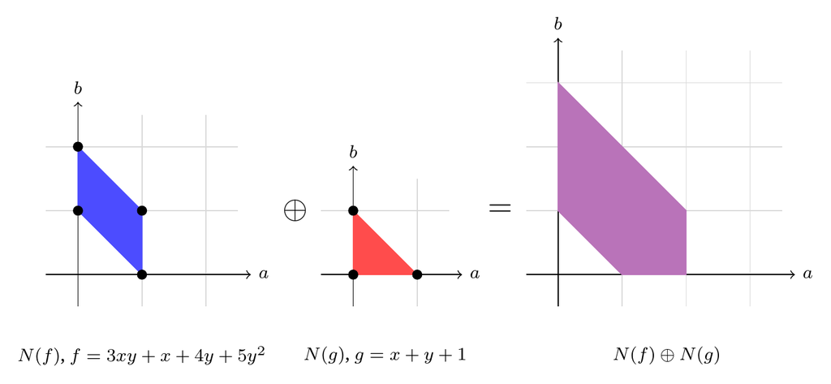

Τα πολύτοπα Newton $N(f), N(g)$ δύο πολυωνύμων και η άθροισή τους Minkowski $N(f)\oplus N(g)$ — η γεωμετρική κατασκευή πάνω στην οποία στηρίζεται το θεώρημα BKK.

**ΣημαντικόΘεώρημα (Bernstein–Kushnirenko–Khovanskii, “BKK”)**

Έστω $f_1,\dots,f_n \in K[x_1^{\pm1},\dots,x_n^{\pm1}]$. Το πλήθος των **απομονωμένων** κοινών ριζών στο $(K^*)^n$ (δηλαδή με όλες τις συντεταγμένες $\neq 0$) φράσσεται από
$$\operatorname{MV}\bigl(N(f_1),\dots,N(f_n)\bigr),$$
και για “γενικούς” συντελεστές (δοθέντων των στηριγμάτων) η ισότητα ισχύει. Αυτό το φράγμα είναι πάντα $\le$ το φράγμα Bézout $d_1\cdots d_n$ (όπου $d_i = \deg f_i$), και συχνά αυστηρά μικρότερο για αραιά συστήματα.

Το θεώρημα BKK είναι η “σωστή” γενίκευση του θεωρήματος Bezout για αραιά συστήματα — αντικαθιστά τους ολικούς βαθμούς με τη γεωμετρία των πολυτόπων Newton. Η **αραιή απαλοίφουσα** (sparse resultant) γενικεύει με τη σειρά της την απαλοίφουσα Sylvester/Macaulay χρησιμοποιώντας ακριβώς αυτά τα πολύτοπα αντί για ομοιόμορφους βαθμούς (θέμα εργασίας εξαμήνου — βλ. §Θέματα εργασιών εξαμήνου).

```julia
Re, xe = polynomial_ring(QQ, :x)
fe, g1e, g2e = xe^2 + 1, xe - 2, xe + 3
resultant(fe, g1e*g2e) == resultant(fe, g1e) * resultant(fe, g2e)
```

```
true
```

Αυτή είναι ακριβώς η ιδιότητα (4) που αναφέραμε παραπάνω, εφαρμοσμένη στο δεύτερο όρισμα αντί στο πρώτο (ισοδύναμη λόγω της αντισυμμετρίας $\operatorname{Res}(f,g)=(-1)^{d_1d_2}\operatorname{Res}(g,f)$). Εννοιολογικά: το $g_1g_2$ έχει κοινή ρίζα με το $f$ ακριβώς όταν έχει κοινή ρίζα είτε το $g_1$ είτε το $g_2$, και ο τύπος Poisson $\operatorname{Res}(f,g)=a_{d_1}^{\deg g}\prod_i g(\xi_i)$ μετατρέπει αυτή τη λογική διάζευξη σε γινόμενο, αφού $\prod_i (g_1g_2)(\xi_i) = \prod_i g_1(\xi_i) \cdot \prod_i g_2(\xi_i)$.

**ΠροσοχήΣύνοψη**

- Η **απαλοίφουσα** (πίνακας Sylvester) μηδενίζεται ακριβώς όταν δύο πολυώνυμα έχουν κοινό παράγοντα — γενίκευση της διακρίνουσας.
- Η ίδια απαλοίφουσα υπολογίζει πολυώνυμα με ρίζα το **άθροισμα/γινόμενο** δύο αλγεβρικών αριθμών — αριθμητική στο $\mathbb{R}_{\mathrm{alg}}$.
- Γενικεύσεις: απαλοίφουσα **Macaulay** για $n$ μορφές σε $n$ μεταβλητές, θεώρημα **Bezout**, θεώρημα **BKK** για αραιά συστήματα (μεικτός όγκος πολυτόπων Newton, συχνά αυστηρά καλύτερο από το φράγμα Bézout).
- Εφαρμογές: implicitization παραμετρικών καμπυλών· θα ξαναδούμε την ίδια λογική απαλοιφής αργότερα με βάσεις Gröbner.

# 6 Θεωρία Ιδεωδών

## 6.1 Ιδεώδη

**ΣημείωσηΟρισμός (Ιδεώδες) (Bandini, Gianni, και Sbarra 2024, τ. 159, κεφ. 1.1)**

Έστω $R$ δακτύλιος και $I \subseteq R$. Το $I$ λέγεται **ιδεώδες** του $R$ αν και μόνο αν:

1. $a, b \in I \implies a + b \in I$,
2. $a \in I, \ r \in R \implies ra \in I$.

Το ιδεώδες που παράγεται από στοιχεία $g_1, \dots, g_n \in R$ είναι
$$\langle g_1, \dots, g_n \rangle = \left\{ \sum_{i=1}^n r_i g_i : r_i \in R \right\}.$$

**Παράδειγμα.** Στο $R = \mathbb{Z}$, το ιδεώδες $\langle 2, 8 \rangle = \{2a_1 + 8a_2 : a_1, a_2 \in \mathbb{Z}\}$ ταυτίζεται με το $2\mathbb{Z}$, ενώ το $\langle 3, 8 \rangle = \mathbb{Z}$ αφού $\gcd(3,8) = 1$. Η **ταυτότητα Bézout** εγγυάται ότι για $a, b \in \mathbb{Z}$ υπάρχουν $x, y \in \mathbb{Z}$ με $\gcd(a,b) = ax + by$:

```julia
gcdx(3, 8)   # (gcd, x, y) ώστε 3x + 8y = gcd
```

```
(1, 3, -1)
```

```julia
I_Z = ideal(ZZ, [3, 8])
isone(I_Z)
```

```
true
```

**ΣυμβουλήΤο πρόβλημα του Ideal Membership**

Δοθέντος ιδεώδους $I = \langle g_1, \dots, g_k \rangle \unlhd R$ και στοιχείου $b \in R$, πώς αποφασίζουμε αν $b \in I$; Για $R = \mathbb{Z}$ αρκεί ο υπολογισμός του $\gcd(g_1,\dots,g_k)$ (Ευκλείδειος αλγόριθμος). Για $R = K[x_1,\dots,x_n]$ με $n \ge 2$ το ερώτημα είναι πολύ πιο δύσκολο, και η απάντηση δόθηκε αλγοριθμικά από τον **Bruno Buchberger** το 1965, χτίζοντας πάνω σε θεμελιώδη αποτελέσματα των Hilbert, Noether και Hermann — αυτός είναι και ο κεντρικός στόχος αυτού του μαθήματος.

Κάθε Ευκλείδεια περιοχή είναι **Περιοχή Κυρίων Ιδεωδών** (Principal Ideal Domain, PID): κάθε ιδεώδες παράγεται από ένα μόνο στοιχείο (το ΜΚΔ των γεννητόρων του) (Bandini, Gianni, και Sbarra 2024, τ. 159, κεφ. 1.6). Ειδικότερα αυτό ισχύει για τον $\mathbb{Z}$ και τον $K[x]$.

**Παράδειγμα.** Στο $R = K[x]$, το ιδεώδες $I = \langle x^2 - 4, \, x - 2 \rangle$ ταυτίζεται με το $\langle x - 2 \rangle$, αφού $x^2 - 4 = (x-2)(x+2)$:

```julia
I1 = ideal(R, [x^2 - 4, x - 2])
I2 = ideal(R, [x - 2])
I1 == I2
```

```
true
```

```julia
gens(I1)
```

```
1-element Vector{QQPolyRingElem}:
 x - 2
```

**Παράδειγμα.** Το ιδεώδες $\langle x - 2, \, x + 2 \rangle$ είναι όλο το $R$, αφού $\gcd(x-2, x+2) = 1$ (τα $x-2, x+2$ είναι σχετικά πρώτα):

```julia
gcd(x - 2, x + 2)
```

$1$

```julia
I3 = ideal(R, [x - 2, x + 2])
isone(I3)
```

```
true
```

**ΣυμβουλήΆσκηση (Bandini, Gianni, και Sbarra 2024, Άσκ. 8.20 — Πράξεις στο $\mathbb{Z}$)**

Έστω $I = \langle m \rangle$, $J = \langle n \rangle$ ιδεώδη του $\mathbb{Z}$. Δείξτε ότι $I + J = \langle \gcd(m,n) \rangle$, $I \cap J = \langle \operatorname{lcm}(m,n) \rangle$, και $IJ = \langle mn \rangle$.

Δοκιμάζουμε την ισότητα υπολογιστικά για $m=12$, $n=18$ (όπου $\gcd(12,18)=6$, $\operatorname{lcm}(12,18)=36$, $mn=216$), συγκρίνοντας τα ιδεώδη ως σύνολα (το OSCAR ελέγχει ισότητα ιδεωδών, όχι απλώς ισότητα γεννητόρων):

```julia
m, n = 12, 18
Im, Jn = ideal(ZZ, [m]), ideal(ZZ, [n])
Im + Jn == ideal(ZZ, [gcd(m, n)]), intersect(Im, Jn) == ideal(ZZ, [lcm(m, n)]), Im * Jn == ideal(ZZ, [m * n])
```

```
(true, true, true)
```

Και οι τρεις ισότητες επαληθεύονται. Ο λόγος είναι γενικός: το $I+J$ είναι το μικρότερο ιδεώδες που περιέχει τα $m,n$, άρα παράγεται από τον $\gcd$ τους· το $I \cap J$ είναι τα κοινά πολλαπλάσια, άρα το $\operatorname{lcm}$· και το $IJ$ παράγεται από όλα τα γινόμενα $am \cdot bn = (ab)(mn)$, δηλαδή από το $mn$.

## 6.2 Μεγιστικά, ριζικά και πρωτεύοντα ιδεώδη

Βλ. (Bandini, Gianni, και Sbarra 2024, τ. 159, κεφ. 1.1).

**ΣημείωσηΟρισμός (Μεγιστικό ιδεώδες)**

Ένα γνήσιο ιδεώδες $I$ του $R$ λέγεται **μεγιστικό** (maximal) αν δεν περιέχεται γνησίως σε κανένα άλλο γνήσιο ιδεώδες του $R$.

Κάθε δακτύλιος $R \neq 0$ έχει τουλάχιστον ένα μεγιστικό ιδεώδες (Λήμμα του Zorn). Στο $\mathbb{Z}$, τα μεγιστικά ιδεώδη είναι ακριβώς τα $\langle p \rangle$ για $p$ πρώτο. Στο $K[x,y]$, το $\langle x,y \rangle$ είναι μεγιστικό, αφού $K[x,y]/\langle x,y \rangle \cong K$ είναι σώμα.

**ΣημείωσηΟρισμός (Ριζικό ιδεώδους, ριζικό ιδεώδες)**

Το **ριζικό** ενός ιδεώδους $I \unlhd R$ είναι
$$\sqrt{I} = \{ a \in R : a^n \in I \ \text{για κάποιο} \ n \in \mathbb{N} \}.$$
Το $I$ λέγεται **ριζικό** (radical) αν $\sqrt{I} = I$.

**ΣημείωσηΟρισμός (Πρώτο ιδεώδες, πρωτεύον ιδεώδες)**

Έστω $I$ γνήσιο ιδεώδες του $R$. Το $I$ λέγεται:

- **πρώτο** (prime) αν $ab \in I \implies a \in I \ \text{ή} \ b \in I$,
- **πρωτεύον** (primary) αν $ab \in I \implies a \in I \ \text{ή} \ b \in \sqrt{I}$.

Παρατηρήστε ότι η έννοια του πρώτου ιδεώδους γενικεύει ακριβώς τον ορισμό της ακέραιας περιοχής από νωρίτερα: το $\langle 0 \rangle$ είναι πρώτο ιδεώδες του $R$ αν και μόνο αν ο $R$ είναι ακέραια περιοχή.

**ΣημαντικόΘεώρημα (Χαρακτηρισμός μέσω δακτυλίου πηλίκου)**

Έστω $I$ ιδεώδες του $R$. Τότε:

1. το $I$ είναι γνήσιο $\iff R/I \neq 0$·
2. το $I$ είναι μεγιστικό $\iff R/I$ είναι σώμα·
3. το $I$ είναι πρώτο $\iff R/I$ είναι ακέραια περιοχή·
4. το $I$ είναι ριζικό $\iff R/I$ δεν έχει μηδενοδύναμα στοιχεία εκτός του $0$.

**ΣημαντικόΘεώρημα**

1. Αν το $I$ είναι πρωτεύον, τότε το $\sqrt{I}$ είναι πρώτο (λέμε τότε ότι το $I$ είναι $\sqrt{I}$-πρωτεύον).
2. Αν το $I$ είναι μεγιστικό, τότε είναι πρωτεύον.

**Παραδείγματα.** Στο $K[x,y]$: το $\langle x \rangle$ είναι πρώτο (το πηλίκο $K[x,y]/\langle x \rangle \cong K[y]$ είναι ακέραια περιοχή)· το $\langle x^2 \rangle$ δεν είναι πρώτο, αλλά **είναι** πρωτεύον, με $\sqrt{\langle x^2 \rangle} = \langle x \rangle$· το $\langle xy \rangle$ **δεν** είναι ούτε πρώτο ούτε πρωτεύον ($xy \in \langle xy \rangle$, αλλά ούτε $x$ ούτε $y$ ανήκουν στο $\sqrt{\langle xy \rangle} = \langle xy \rangle$, αφού το $xy$ είναι ήδη χωρίς τετράγωνα)· το $\langle x, y^2 \rangle$ είναι πρωτεύον με $\sqrt{\langle x,y^2\rangle} = \langle x,y \rangle$ μεγιστικό, αν και το ίδιο **δεν** είναι δύναμη πρώτου ιδεώδους — δείχνει ότι η έννοια του πρωτεύοντος είναι γνήσια ευρύτερη από “δύναμη πρώτου”.

```julia
Rp, (xp, yp) = polynomial_ring(QQ, [:x, :y])
examples = [
    "<x>"     => ideal(Rp, [xp]),
    "<x,y>"   => ideal(Rp, [xp, yp]),
    "<x^2>"   => ideal(Rp, [xp^2]),
    "<x*y>"   => ideal(Rp, [xp*yp]),
    "<x,y^2>" => ideal(Rp, [xp, yp^2]),
]
[(name, is_prime(I), is_primary(I), radical(I)) for (name, I) in examples]
```

```
5-element Vector{Tuple{String, Bool, Bool, MPolyIdeal{QQMPolyRingElem}}}:
 ("<x>", 1, 1, Ideal (x))
 ("<x,y>", 1, 1, Ideal (x, y))
 ("<x^2>", 0, 1, Ideal (x))
 ("<x*y>", 0, 0, Ideal (x*y))
 ("<x,y^2>", 0, 1, Ideal (x, y))
```

**ΠροσοχήΣύνοψη**

- **Ιδεώδες**: υποσύνολο ενός δακτυλίου κλειστό ως προς πρόσθεση και πολλαπλασιασμό με στοιχεία του δακτυλίου· γεννήτορες, βάση.
- Το πρόβλημα του **ideal membership** ($f \in I$;) είναι το κεντρικό υπολογιστικό ερώτημα του μαθήματος — θα το λύσουμε αλγοριθμικά με βάσεις Gröbner.
- Μεγιστικά, πρώτα και ριζικά ιδεώδη χαρακτηρίζονται μέσω ιδιοτήτων του δακτυλίου πηλίκου $R/I$ (σώμα, ακέραια περιοχή, ή μηδενικό ριζικό).

# 7 Πολυώνυμα Πολλών Μεταβλητών και Αναγωγή

## 7.1 Δακτύλιος πολυωνύμων πολλών μεταβλητών

Οι ορισμοί αυτής και της επόμενης ενότητας ακολουθούν το (Bandini, Gianni, και Sbarra 2024, τ. 159, κεφ. 2.1–2.2) (βλ. επίσης (Cox, Little, και O’Shea 2007, κεφ. 2, §2)).

**ΣημείωσηΟρισμός (Μονοειδές όρων)**

Το σύνολο $[x_1, \dots, x_n] = \{ x^a = x_1^{a_1} x_2^{a_2} \cdots x_n^{a_n} : a = (a_1, \dots, a_n) \in \mathbb{N}^n \}$, με πράξη $x^a \cdot x^b = x^{a+b}$, λέγεται **μονοειδές όρων** (term monoid). Είναι ισόμορφο, ως πολλαπλασιαστικό μονοειδές, με το $(\mathbb{N}^n, +)$.

**ΣημείωσηΟρισμός (Δακτύλιος πολυωνύμων $n$ μεταβλητών)**

$$K[x_1, \dots, x_n] = \left\{ \sum_{m \in [x_1,\dots,x_n]} c_m \, m \ : \ c_m \in K, \ \text{πεπερασμένου πλήθους } c_m \neq 0 \right\}.$$
Είναι δηλαδή ένας $K$-διανυσματικός χώρος με βάση το σύνολο των μονωνύμων $[x_1, \dots, x_n]$.

**ΣημείωσηΟρισμός (Βαθμός)**

Ο βαθμός του όρου $x^a = x_1^{a_1} \cdots x_n^{a_n}$ είναι $\deg(x^a) = |a| = a_1 + \cdots + a_n$. Ο βαθμός ενός πολυωνύμου είναι ο μέγιστος βαθμός όρου που εμφανίζεται σε αυτό με μη μηδενικό συντελεστή.

```julia
R, (x, y, z) = polynomial_ring(QQ, [:x, :y, :z])
f = x^2*y^3 + 4x*y*z - z^5
total_degree(f)
```

```
5
```

```julia
collect(terms(f))
```

```
3-element Vector{QQMPolyRingElem}:
 x^2*y^3
 -z^5
 4*x*y*z
```

## 7.2 Διατάξεις όρων

**ΣημείωσηΟρισμός (Διάταξη όρων)**

Μια διάταξη $<$ στο $T = [x_1, \dots, x_n]$ λέγεται **διάταξη όρων** αν και μόνο αν:

- είναι ολική (και καλή) διάταξη στο $T$,
- $1 \le a$ για κάθε $a \in T$,
- $a < b \implies ac < bc$ για κάθε $a, b, c \in T$.

Οι πιο συνηθισμένες διατάξεις όρων είναι:

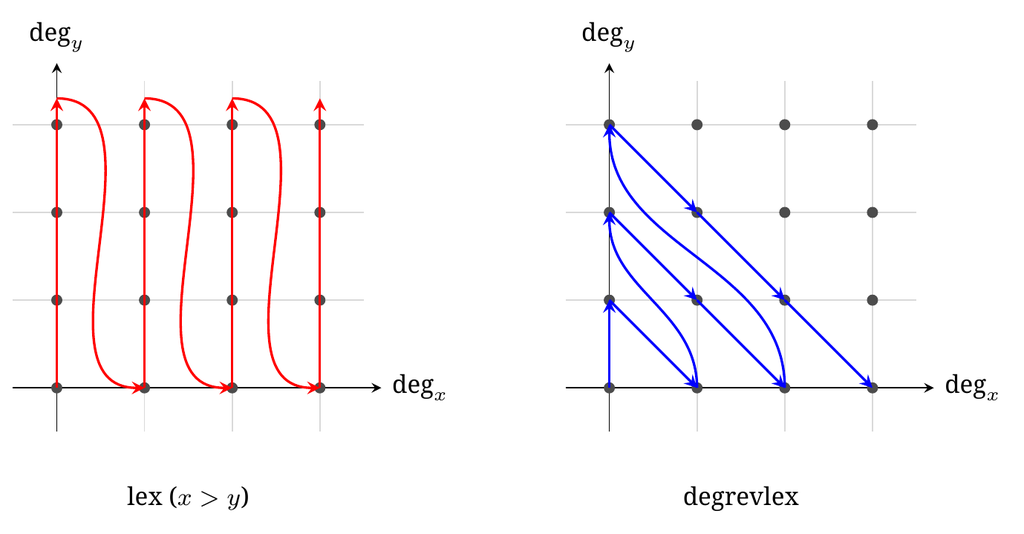

Σύγκριση lex και degrevlex στο μονοειδές όρων $[x,y]$ (με $x>y$): τα βέλη δείχνουν τη φορά αύξησης. Η lex διατρέχει στήλη-στήλη (πρώτα ο εκθέτης του $x$)· η degrevlex διατρέχει διαγώνιο-διαγώνιο (πρώτα ο ολικός βαθμός).

Στο OSCAR:

```julia
o_lex, o_dl, o_drl = lex(R), deglex(R), degrevlex(R)
```

```
(lex([x, y, z]), deglex([x, y, z]), degrevlex([x, y, z]))
```

**Παράδειγμα.** Τα $y^2$ και $xz$ έχουν και τα δύο βαθμό $2$, αλλά διατάσσονται αντίστροφα στις δύο διατάξεις:

```julia
cmp(o_lex, y^2, x*z)   # αρνητικό <=> y^2 < xz
```

```
-1
```

```julia
cmp(o_drl, y^2, x*z)   # θετικό <=> y^2 > xz
```

```
1
```

Δοθείσας μιας διάταξης όρων, κάθε μη μηδενικό $f \in K[x_1,\dots,x_n]$ γράφεται μονοσήμαντα ως $f = c_1 t_1 + c_2 t_2 + \cdots + c_m t_m$ με $c_i \in K^*$ και $t_1 > t_2 > \cdots > t_m$ όρους· ορίζουμε τον **μεγιστοβάθμιο συντελεστή** $\operatorname{lc}(f) = c_1$, τον **μεγιστοβάθμιο όρο** $\operatorname{lt}(f) = c_1 t_1$ και το **μεγιστοβάθμιο μονώνυμο** $\operatorname{lm}(f) = t_1$:

```julia
g = x^3 + x^2*y - y^2
leading_term(g, ordering = o_lex), leading_term(g, ordering = o_drl)
```

```
(x^3, x^3)
```

**ΣυμβουλήΆσκηση (Bandini, Gianni, και Sbarra 2024, Άσκ. 9.2)**

Αποδείξτε ότι οι lex, deglex, degrevlex είναι πράγματι διατάξεις όρων.

Ελέγχουμε (όχι ως απόδειξη, αλλά ως εμπειρικό τεστ) την ιδιότητα συμβατότητας $a < b \implies ac < bc$ σε τυχαία μονώνυμα:

```julia
function check_compatible(o; trials = 300)
    for _ in 1:trials
        expa, expb, expc = (rand(0:4,3) for _ in 1:3)
        ma, mb, mc = x^expa[1]*y^expa[2]*z^expa[3], x^expb[1]*y^expb[2]*z^expb[3], x^expc[1]*y^expc[2]*z^expc[3]
        if cmp(o, ma, mb) < 0 && cmp(o, ma*mc, mb*mc) >= 0
            return false
        end
    end
    return true
end

check_compatible(o_lex), check_compatible(o_dl), check_compatible(o_drl)
```

```
(true, true, true)
```

Και οι τρεις διατάξεις περνούν το τεστ. Η πραγματική απόδειξη είναι άμεση από τους ορισμούς: αν $a<_{\text{lex}} b$ λόγω διαφοράς σε κάποια συντεταγμένη $i$ (με $a_j=b_j$ για $j<i$), τότε οι πρώτες $i-1$ συντεταγμένες των $a+c, b+c$ παραμένουν ίσες και η $i$-οστή διατηρεί την ανισότητα, άρα $a+c <_{\text{lex}} b+c$. Για τις deglex/degrevlex, η πρόσθεση του $c$ αυξάνει και τους δύο βαθμούς κατά $|c|$, οπότε η σύγκριση βαθμών (ή η δευτερεύουσα λεξικογραφική/αντίστροφη σύγκριση όταν οι βαθμοί ισούνται) παραμένει ανεπηρέαστη.

## 7.3 Αναγωγή ως προς λίστα πολυωνύμων

Βλ. (Bandini, Gianni, και Sbarra 2024, τ. 159, κεφ. 2.3) και (Cox, Little, και O’Shea 2007, κεφ. 2, §3).

**ΣημείωσηΟρισμός (Αναγωγή / Reduction)**

Έστω $B = \{b_1, \dots, b_k\} \subseteq K[x_1,\dots,x_n] \setminus \{0\}$ και μια διάταξη όρων $<$. Λέμε ότι το $a$ **ανάγεται** στο $r$ ως προς το $B$ (γράφουμε $a \xrightarrow{B} r$) αν
$$a = q_1 b_1 + \cdots + q_k b_k + r$$
για κάποια $q_i \in K[x_1,\dots,x_n]$, και κανένας όρος του $r$ δεν διαιρείται από κανένα $\operatorname{lt}(b_i)$.

Ο αλγόριθμος αναγωγής λειτουργεί ακριβώς όπως η ευκλείδεια διαίρεση, αλλά σε κάθε βήμα δοκιμάζει όλα τα $b_i \in B$:

```
def reduce(a, B):
    r = 0
    while a ≠ 0:
        αν υπάρχει i με lt(b_i) | lt(a):
            a = a - (lt(a) / lt(b_i)) * b_i
        αλλιώς:
            r = r + lt(a)
            a = a - lt(a)
    return r
```

Υλοποιούμε τον αλγόριθμο αυτόν κατά λέξη, ώστε να δούμε ακριβώς τη συμπεριφορά του (η σειρά των $b_i$ στο $B$ έχει σημασία!):

```julia
function naive_reduce(a, B, o)
    r = zero(parent(a))
    while !iszero(a)
        la = leading_term(a, ordering = o)
        i = findfirst(b -> divides(la, leading_term(b, ordering = o))[1], B)
        if i !== nothing
            a -= divexact(la, leading_term(B[i], ordering = o)) * B[i]
        else
            r += la
            a -= la
        end
    end
    return r
end

f = x^2*y + x*y^2 + y^2
naive_reduce(f, [x*y - 1, y^2 - 1], o_lex)
```

$x + y + 1$

**Προειδοποίηση**

Σε αντίθεση με τη μονομεταβλητή διαίρεση, το υπόλοιπο $r$ **δεν είναι πάντα μοναδικό** — μπορεί να εξαρτάται από τη σειρά με την οποία δοκιμάζουμε τα $b_i \in B$. Θα δούμε παρακάτω ότι η μοναδικότητα αποκαθίσταται όταν το $B$ είναι **βάση Gröbner**.

**ΣυμβουλήΆσκηση (Bandini, Gianni, και Sbarra 2024, Άσκ. 9.5)**

Έστω $f = x_1^4 x_2$ και $F = \{f_1, f_2\} = \{x_1^3, \, x_1^2 x_2 - x_2^2\} \subseteq \mathbb{Q}[x_1,x_2]$, με τη lex διάταξη $x_1 > x_2$. Δείξτε ότι το υπόλοιπο της διαίρεσης του $f$ με το $F$ δεν είναι μοναδικό.

Δοκιμάζουμε τον `naive_reduce` με τη λίστα $F$ στις δύο δυνατές σειρές:

```julia
R2, (x1, x2) = polynomial_ring(QQ, [:x1, :x2])
o2 = lex(R2)
f95 = x1^4 * x2

naive_reduce(f95, [x1^3, x1^2*x2 - x2^2], o2), naive_reduce(f95, [x1^2*x2 - x2^2, x1^3], o2)
```

```
(0, x2^3)
```

Πράγματι, τα δύο υπόλοιπα διαφέρουν ($0$ και $x_2^3$ αντίστοιχα, ανάλογα με τη σειρά). Αξίζει να σημειωθεί ότι η ενσωματωμένη `reduce` του OSCAR είναι πιο έξυπνη από τον αφελή αλγόριθμο και επιστρέφει $0$ και στις δύο περιπτώσεις:

```julia
reduce(f95, [x1^3, x1^2*x2 - x2^2], ordering = o2), reduce(f95, [x1^2*x2 - x2^2, x1^3], ordering = o2)
```

```
(0, 0)
```

**ΠροσοχήΣύνοψη**

- Το $K[x_1,\dots,x_n]$ ορίζεται αναδρομικά· το μονοειδές όρων $[x_1,\dots,x_n]$ αντιστοιχεί σε $\mathbb{N}^n$ μέσω μιας φυσικής (πολλαπλο-δεικτικής) αντιστοιχίας.
- Μια **διάταξη όρων** (lex, degrevlex, κ.ά.) είναι απαραίτητη για να ορίσουμε μοναδικά τον μεγιστοβάθμιο όρο ενός πολυωνύμου πολλών μεταβλητών.
- Ο αλγόριθμος **αναγωγής** γενικεύει την Ευκλείδεια διαίρεση σε πολλές μεταβλητές/πολλούς διαιρέτες — αλλά, εν γένει, το αποτέλεσμα εξαρτάται από τις επιλογές μας κατά την εκτέλεση, εκτός αν η λίστα διαιρετών είναι βάση Gröbner.

# 8 Μονωνυμικά Ιδεώδη και το Θεώρημα Βάσης του Hilbert

## 8.1 Μονωνυμικά ιδεώδη και βάσεις Gröbner

**ΣημείωσηΟρισμός (Μονωνυμικό ιδεώδες) (Bandini, Gianni, και Sbarra 2024, τ. 159, κεφ. 2.1)**

Ένα ιδεώδες $I \unlhd K[x_1,\dots,x_n]$ λέγεται **μονωνυμικό** αν παράγεται από μονώνυμα, δηλαδή $I = \langle x^a : a \in E \rangle$ για κάποιο $E \subseteq \mathbb{N}^n$.

**ΣημαντικόΘεώρημα (Λήμμα Dickson)**

Κάθε μονωνυμικό ιδεώδες του $K[x_1,\dots,x_n]$ παράγεται από **πεπερασμένο** πλήθος μονωνύμων.

Η απόδειξη γίνεται με επαγωγή στο $n$: για $n=1$ αρκεί το ελάχιστο εκθέτη· για το επαγωγικό βήμα προβάλλουμε στις πρώτες $n-1$ μεταβλητές, εφαρμόζουμε την επαγωγική υπόθεση, και δείχνουμε ότι πεπερασμένες “φέτες” ως προς την τελευταία μεταβλητή αρκούν (βλ. (Bandini, Gianni, και Sbarra 2024, τ. 159, κεφ. 2.1) ή (Cox, Little, και O’Shea 2007, κεφ. 2, §4)).

**ΣημείωσηΟρισμός (Μεγιστοβάθμιο ιδεώδες, βάση Gröbner) (Bandini, Gianni, και Sbarra 2024, τ. 159, κεφ. 2.4)**

Έστω $I \unlhd K[x_1,\dots,x_n]$ ιδεώδες και $<$ διάταξη όρων. Το **μεγιστοβάθμιο ιδεώδες** του $I$ είναι
$$\operatorname{LT}(I) = \langle \operatorname{lt}(f) : f \in I, \, f \neq 0 \rangle.$$
Ένα πεπερασμένο σύνολο $G = \{g_1, \dots, g_m\} \subseteq I$ λέγεται **βάση Gröbner** του $I$ ως προς $<$ αν
$$\langle \operatorname{lt}(g_1), \dots, \operatorname{lt}(g_m) \rangle = \operatorname{LT}(I).$$

Το $\operatorname{LT}(I)$ είναι πάντα μονωνυμικό ιδεώδες, άρα από το Λήμμα Dickson παράγεται πεπερασμένα — αυτό εγγυάται ότι **κάθε ιδεώδες έχει βάση Gröbner** (πεπερασμένη) ως προς οποιαδήποτε διάταξη όρων.

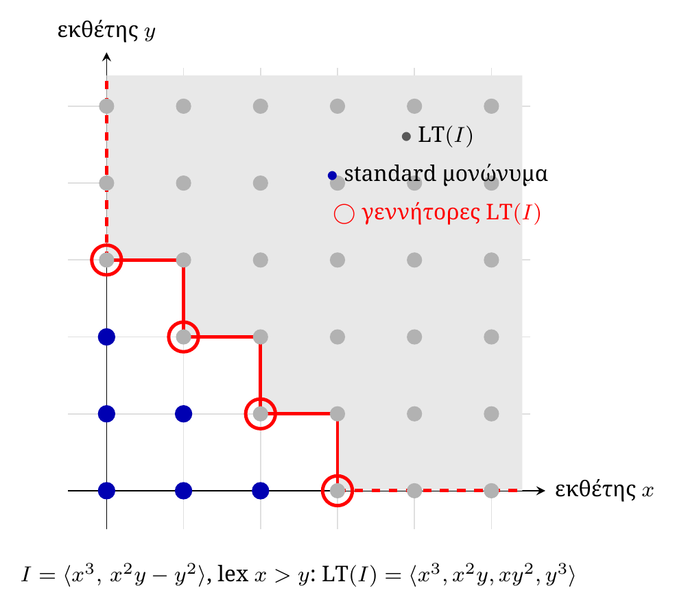

Η “σκάλα” (staircase) του $\operatorname{LT}(I)$ για $I=\langle x^3,x^2y-y^2\rangle$ ως προς lex ($x>y$): τα γκρι σημεία είναι στο $\operatorname{LT}(I)$, τα μπλε είναι τα standard μονώνυμα, και οι κόκκινοι κύκλοι δείχνουν τους γεννήτορες του $\operatorname{LT}(I)$ (τις “εσωτερικές γωνίες” της σκάλας).

```julia
I = ideal(R, [x^3, x^2*y - y^2])
leading_ideal(I, ordering = o_lex)
```

```
Ideal generated by
  y^3
  x*y^2
  x^2*y
  x^3
```

```julia
G = groebner_basis(I, ordering = o_lex)
G
```

```
Gröbner basis with elements
  1: y^3
  2: x*y^2
  3: x^2*y - y^2
  4: x^3
with respect to the ordering
  lex([x, y, z])
```

```julia
leading_ideal(I, ordering = o_lex) == ideal(R, [leading_term(g, ordering = o_lex) for g in G])
```

```
true
```

**ΣυμβουλήΆσκηση (Cox, Little, και O’Shea 2007, κεφ. 2, §5, Άσκ. 1)**

Έστω $I = \langle g_1, g_2, g_3 \rangle \subseteq K[x,y,z]$ όπου $g_1 = xy^2 - xz + y$, $g_2 = xy - z^2$, $g_3 = x - yz^4$. Ως προς τη lex διάταξη, βρείτε ένα $g \in I$ με $\operatorname{lt}(g) \notin \langle \operatorname{lt}(g_1), \operatorname{lt}(g_2), \operatorname{lt}(g_3) \rangle$ — δηλαδή δείξτε ότι το $\{g_1,g_2,g_3\}$ **δεν** είναι βάση Gröbner.

Πρώτα επιβεβαιώνουμε ότι το $\{g_1,g_2,g_3\}$ όντως αποτυγχάνει να είναι βάση Gröbner, συγκρίνοντας το πραγματικό $\operatorname{LT}(I)$ (υπολογισμένο μέσω `leading_ideal`, που εσωτερικά τρέχει τον αλγόριθμο Buchberger) με το ιδεώδες $\langle \operatorname{lt}(g_1),\operatorname{lt}(g_2),\operatorname{lt}(g_3)\rangle$ που παράγουν οι δοθέντες γεννήτορες:

```julia
Rg, (xg, yg, zg) = polynomial_ring(QQ, [:x, :y, :z])
og = lex(Rg)
g1e, g2e, g3e = xg*yg^2 - xg*zg + yg, xg*yg - zg^2, xg - yg*zg^4
Ie = ideal(Rg, [g1e, g2e, g3e])

leading_ideal(Ie, ordering = og) == ideal(Rg, [leading_term(p, ordering = og) for p in [g1e,g2e,g3e]])
```

```
false
```

Αφού τα δύο ιδεώδη **δεν** ταυτίζονται (`false`), υπάρχει κάποιο $g \in I$ με $\operatorname{lt}(g)$ εκτός του $\langle \operatorname{lt}(g_1),\operatorname{lt}(g_2),\operatorname{lt}(g_3) \rangle$. Ένα τέτοιο $g$ βρίσκεται πάντα ανάμεσα στα S-πολυώνυμα των γεννητόρων (θα δούμε γιατί στο κριτήριο του Buchberger παρακάτω) — δοκιμάζουμε το $\operatorname{spol}(g_1,g_2)$ και το ανάγουμε ως προς τη λίστα:

```julia
Lg = lcm(leading_monomial(g1e, ordering = og), leading_monomial(g2e, ordering = og))
gwitness = divexact(Lg, leading_term(g1e, ordering = og)) * g1e - divexact(Lg, leading_term(g2e, ordering = og)) * g2e
reduce(gwitness, [g1e, g2e, g3e], ordering = og)   # μη μηδενικό, με μεγιστοβάθμιο όρο εκτός <lt(g1),lt(g2),lt(g3)>
```

$-y z^{5} + y z^{2} + y$

Το μη μηδενικό αυτό υπόλοιπο είναι το ζητούμενο $g$: ανήκει στο $I$ (είναι $K[x,y,z]$-γραμμικός συνδυασμός των $g_1,g_2,g_3$), αλλά ο μεγιστοβάθμιος όρος του δεν διαιρείται από κανέναν από τους $\operatorname{lt}(g_i)$, άρα δεν ανήκει στο $\langle \operatorname{lt}(g_1),\operatorname{lt}(g_2),\operatorname{lt}(g_3)\rangle$.

## 8.2 Το Θεώρημα Βάσης του Hilbert

Η ιδέα ότι κάθε ιδεώδες του $K[x_1,\dots,x_n]$ είναι πεπερασμένα παραγόμενο δεν είναι αυτονόητη — κατ’ αρχάς φαίνεται εντελώς διαφορετικό ερώτημα από το Λήμμα Dickson, αφού εκεί περιοριστήκαμε σε μονωνυμικά ιδεώδη. Το θεμελιώδες αυτό αποτέλεσμα οφείλεται στον Hilbert, και εδώ το αποδεικνύουμε μέσω μιας ισοδυναμίας με τη **συνθήκη αύξουσας αλυσίδας**, ακολουθώντας το (Waerden 1950, τ. 2, κεφ. XII, §84) (βλ. επίσης (Bandini, Gianni, και Sbarra 2024, τ. 159, κεφ. 7.2, Θ. 7.4) και (Cox, Little, και O’Shea 2007, κεφ. 2, §5)).

**ΣημείωσηΟρισμός (ACC — Ascending Chain Condition)**

Ένας δακτύλιος $R$ ικανοποιεί τη **συνθήκη αύξουσας αλυσίδας** (ACC) αν για κάθε αλυσίδα ιδεωδών $I_1 \subseteq I_2 \subseteq \cdots$ του $R$ υπάρχει $n \in \mathbb{N}$ ώστε $I_k = I_n$ για κάθε $k \ge n$.

**ΣημαντικόΘεώρημα**

Ένας δακτύλιος $R$ ικανοποιεί την ACC αν και μόνο αν κάθε ιδεώδες του $R$ είναι πεπερασμένα παραγόμενο (δηλαδή ο $R$ είναι **Noetherian**).

**Απόδειξη.** ($\Rightarrow$) Έστω $I \unlhd R$ μη πεπερασμένα παραγόμενο. Επιλέγουμε $g_1 \in I$, και επαγωγικά $g_{k} \in I \setminus \langle g_1, \dots, g_{k-1} \rangle$ (υπάρχει τέτοιο στοιχείο ακριβώς επειδή το $I$ δεν παράγεται πεπερασμένα από τα $g_1,\dots,g_{k-1}$). Τότε
$$\langle g_1 \rangle \subsetneq \langle g_1, g_2 \rangle \subsetneq \langle g_1, g_2, g_3 \rangle \subsetneq \cdots$$
είναι μια γνησίως αύξουσα άπειρη αλυσίδα, άτοπο.

($\Leftarrow$) Έστω $I_1 \subseteq I_2 \subseteq \cdots$ αλυσίδα ιδεωδών. Το $I = \bigcup_k I_k$ είναι ιδεώδες (εύκολα, αφού η ένωση είναι επί μιας αλυσίδας), άρα πεπερασμένα παραγόμενο, $I = \langle g_1, \dots, g_m \rangle$. Κάθε $g_i$ ανήκει σε κάποιο $I_{k_i}$· θέτοντας $n = \max(k_1,\dots,k_m)$ έχουμε $I = \langle g_1,\dots,g_m \rangle \subseteq I_n \subseteq I$, άρα $I_k = I_n$ για κάθε $k \ge n$. $\blacksquare$

Η απόδειξη ότι ο $K[x_1,\dots,x_n]$ είναι Noetherian γίνεται τώρα με επαγωγή στο $n$, χρησιμοποιώντας το εξής λήμμα:

**ΣημαντικόΛήμμα**

Αν ο $R$ είναι Noetherian, τότε και ο $R[t]$ είναι Noetherian.

**Απόδειξη (σκιαγράφηση).** Έστω $I \unlhd R[t]$. Για κάθε $d \in \mathbb{N}$ ορίζουμε
$$I_d = \{0\} \cup \{\operatorname{lc}(p) : p \in I, \ \deg(p) = d\} \subseteq R,$$
το σύνολο των μεγιστοβάθμιων συντελεστών των στοιχείων του $I$ βαθμού $d$ (μαζί με το $0$). Κάθε $I_d$ είναι ιδεώδες του $R$, και $I_0 \subseteq I_1 \subseteq \cdots$ (αν $\deg(p)=d$ τότε $\deg(tp) = d+1$ με τον ίδιο μεγιστοβάθμιο συντελεστή). Από την ACC στον $R$, η αλυσίδα σταθεροποιείται σε κάποιο $I_{d_0}$. Επιλέγουμε πεπερασμένους γεννήτορες για κάθε $I_0,\dots,I_{d_0}$ και αντίστοιχα πολυώνυμα $f_{i,j} \in I$ με $\deg(f_{i,j}) = i$ και μεγιστοβάθμιο συντελεστή τον $j$-οστό γεννήτορα του $I_i$. Δείχνουμε ότι το πεπερασμένο σύνολο $\{f_{i,j}\}$ παράγει το $I$: αν όχι, παίρνουμε στοιχείο $p \in I$ ελάχιστου βαθμού $m$ εκτός του παραγόμενου ιδεώδους· γράφοντας $\operatorname{lc}(p)$ ως συνδυασμό των κατάλληλων γεννητόρων (του $I_m$ αν $m \le d_0$, αλλιώς του $I_{d_0}$ πολλαπλασιασμένο με $t^{m-d_0}$), κατασκευάζουμε $q$ στο παραγόμενο ιδεώδες με $\deg(p-q) < m$· η ελαχιστότητα του $m$ αναγκάζει $p - q = 0$, άτοπο. $\blacksquare$

**ΣημαντικόΘεώρημα (Βάση Hilbert)**

Αν $K$ είναι σώμα, ο δακτύλιος $K[x_1,\dots,x_n]$ είναι Noetherian· δηλαδή κάθε ιδεώδες $I \unlhd K[x_1,\dots,x_n]$ είναι πεπερασμένα παραγόμενο.

Η απόδειξη είναι άμεση επαγωγή στο $n$: το $K$ είναι Noetherian (τα μόνα ιδεώδη είναι τα $\langle 0 \rangle, \langle 1 \rangle$), και $K[x_1,\dots,x_n] = K[x_1,\dots,x_{n-1}][x_n]$, οπότε το λήμμα ολοκληρώνει την επαγωγή.

Στην πράξη, το OSCAR δουλεύει πάντα με πεπερασμένους γεννήτορες — όσο “περίπλοκο” και αν είναι ένα ιδεώδες, μια βάση Gröbner του είναι πάντα πεπερασμένη:

```julia
I2 = ideal(R, [x^2, x*y, y^3])
length(groebner_basis(I2, ordering = o_lex))
```

```
3
```

**ΣυμβουλήΆσκηση (Cox, Little, και O’Shea 2007, κεφ. 2, §5, Άσκ. 14)**

Έστω $f_1, f_2, \dots \in K[x_1,\dots,x_n]$ μια (ενδεχομένως άπειρη) οικογένεια πολυωνύμων, και $I = \langle f_1, f_2, \dots \rangle$. Δείξτε ότι υπάρχει $N$ ώστε $I = \langle f_1, \dots, f_N \rangle$.

**Απόδειξη.** Το $I = \langle f_1, f_2, \dots \rangle$ είναι ιδεώδες του $K[x_1,\dots,x_n]$, άρα από το Θεώρημα Βάσης Hilbert είναι πεπερασμένα παραγόμενο: $I = \langle h_1,\dots,h_m \rangle$ για κάποια $h_1,\dots,h_m \in I$. Κάθε $h_i$, ως στοιχείο του $I$, είναι πεπερασμένος συνδυασμός $\sum_j c_{ij} f_j$, άρα εξαρτάται μόνο από πεπερασμένα πολλά $f_j$· έστω $N$ το μέγιστο τέτοιο δείκτη πάνω από όλα τα $i=1,\dots,m$. Τότε κάθε $h_i \in \langle f_1,\dots,f_N \rangle$, άρα $I = \langle h_1,\dots,h_m \rangle \subseteq \langle f_1,\dots,f_N \rangle \subseteq I$, δηλαδή ισότητα. $\blacksquare$

Ας το δούμε υπολογιστικά σε μια “κατά προσέγγιση άπειρη” οικογένεια $20$ γεννητόρων — παρατηρήστε πόσο μικρότερη είναι η βάση Gröbner που προκύπτει σε σχέση με τους $20$ αρχικούς γεννήτορες:

```julia
Rh, (xh, yh) = polynomial_ring(QQ, [:x, :y])
gens20 = [xh^k - xh*yh^(k-1) for k in 1:20]
length(groebner_basis(ideal(Rh, gens20), ordering = lex(Rh)))   # πολύ μικρότερο από 20!
```

```
1
```

Αυτό είναι ακριβώς το φαινόμενο της άσκησης: όλοι οι γεννήτορες πέρα από κάποιο $N$ αποδεικνύονται περιττοί — ήδη ανήκουν στο ιδεώδες που παράγουν οι πρώτοι λίγοι.

**ΠροσοχήΣύνοψη**

- **Λήμμα Dickson**: κάθε μονωνυμικό ιδεώδες παράγεται πεπερασμένα.
- **Βάση Gröbner**: μια βάση $G$ του $I$ είναι βάση Gröbner ακριβώς όταν η αναγωγή ως προς $G$ δίνει μοναδικό αποτέλεσμα (ισοδύναμα, $\langle \operatorname{lt}(G)\rangle = \langle \operatorname{lt}(I)\rangle$).
- **Θεώρημα Βάσης του Hilbert**: κάθε ιδεώδες του $K[x_1,\dots,x_n]$ είναι πεπερασμένα παραγόμενο — εγγυάται ότι μια βάση Gröbner πάντα υπάρχει και είναι πεπερασμένη.

# 9 Ο Αλγόριθμος Buchberger

## 9.1 Ο αλγόριθμος του Buchberger

Ο ορισμός του S-πολυωνύμου, το κριτήριο και ο αλγόριθμος του Buchberger ακολουθούν το (Bandini, Gianni, και Sbarra 2024, τ. 159, κεφ. 2.5) (βλ. επίσης (Cox, Little, και O’Shea 2007, κεφ. 2, §6–7) και, για μια πιο αλγοριθμική/υπολογιστική οπτική στο ίδιο υλικό, (Adams και Loustaunau 1994, τ. 3, κεφ. 2)).

**ΣημείωσηΟρισμός (S-πολυώνυμο)**

Έστω $f, g \in K[x_1,\dots,x_n] \setminus \{0\}$ και $L = \operatorname{lcm}(\operatorname{lm}(f), \operatorname{lm}(g))$. Το **S-πολυώνυμο** των $f, g$ είναι
$$\operatorname{spol}(f,g) = \frac{L}{\operatorname{lt}(f)} f - \frac{L}{\operatorname{lt}(g)} g.$$
Κατασκευαστικά, το $\operatorname{spol}(f,g)$ ακυρώνει τους μεγιστοβάθμιους όρους των $f, g$.

**ΣημαντικόΘεώρημα (Κριτήριο του Buchberger, 1965)**

Ένα σύνολο $G = \{g_1,\dots,g_m\} \subseteq I$ είναι βάση Gröbner του $I$ ως προς $<$ αν και μόνο αν για κάθε $i \neq j$
$$\operatorname{spol}(g_i, g_j) \xrightarrow{G} 0.$$

```
Αλγόριθμος Buchberger
Είσοδος:  I = <f_1,...,f_m> ⊆ K[x_1,...,x_n], διάταξη <
Έξοδος:   βάση Gröbner G του I ως προς <

G = {f_1,...,f_m}
C = {(f_i,f_j) : i < j}
while C ≠ ∅:
    επίλεξε (u,v) ∈ C·  C = C \ {(u,v)}
    r = reduce(spol(u,v), G)
    αν r ≠ 0:
        G = G ∪ {r}
        C = C ∪ {(g,r) : g ∈ G}
return G
```

Επειδή κάθε νέο στοιχείο που προστίθεται στο $G$ αυξάνει το μεγιστοβάθμιο ιδεώδες $\langle \operatorname{lt}(G) \rangle$ (το $r$ δεν ανάγεται σε $0$), και ο $K[x_1,\dots,x_n]$ είναι Noetherian, ο αλγόριθμος τερματίζει.

### 9.1.1 Κριτήρια Buchberger για αποφυγή περιττών ζευγών

Ο αλγόριθμος όπως διατυπώθηκε παραπάνω δοκιμάζει *κάθε* ζεύγος $(u,v) \in C$ — αλλά στην πράξη τα περισσότερα ζεύγη ανάγονται σε $0$ χωρίς να προσθέσουν τίποτα νέο στη βάση, και το να τα ελέγχουμε ένα-ένα σπαταλά υπολογιστική ισχύ (θυμηθείτε τη συζήτηση για την πολυπλοκότητα στην §Πολυπλοκότητα υπολογισμού βάσεων Gröbner — ακριβώς αυτό εκμεταλλεύονται αλγόριθμοι όπως οι F4/F5). Ο Buchberger έδωσε δύο **κριτήρια** που επιτρέπουν να παραλείψουμε ένα ζεύγος *εκ των προτέρων*, χωρίς καν να υπολογίσουμε το S-πολυώνυμό του.

**ΣημαντικόΘεώρημα (Πρώτο κριτήριο — κριτήριο των πρώτων μεταξύ τους μεγιστοβάθμιων όρων)**

Αν $\operatorname{lt}(g_i), \operatorname{lt}(g_j)$ είναι πρώτα μεταξύ τους (δηλαδή $\operatorname{lcm}(\operatorname{lt}(g_i),\operatorname{lt}(g_j)) = \operatorname{lt}(g_i)\cdot\operatorname{lt}(g_j)$), τότε
$$\operatorname{spol}(g_i,g_j) \xrightarrow{\{g_i,g_j\}} 0$$
αυτόματα — το ζεύγος $(g_i,g_j)$ μπορεί να παραλειφθεί χωρίς έλεγχο.

Διαισθητικά: όταν οι μεγιστοβάθμιοι όροι δεν μοιράζονται κοινούς παράγοντες, δεν υπάρχει πραγματική “σύγκρουση” ανάμεσα στα $g_i,g_j$ προς αναγωγή — το S-πολυώνυμο είναι απλώς ένας γραμμικός συνδυασμός που ανάγεται στο $0$ μέσω των ίδιων $g_i,g_j$.

**ΣημαντικόΘεώρημα (Δεύτερο κριτήριο — κριτήριο αλυσίδας/chain criterion)**

Έστω $u,v,p \in G$ τέτοια ώστε $\operatorname{lt}(p) \mid \operatorname{lcm}(\operatorname{lt}(u),\operatorname{lt}(v))$. Αν τα ζεύγη $(u,p)$ και $(p,v)$ έχουν ήδη ελεγχθεί (ή ικανοποιούν το πρώτο κριτήριο), τότε το ζεύγος $(u,v)$ μπορεί κι αυτό να παραλειφθεί.

Δηλαδή αν υπάρχει ένα “ενδιάμεσο” στοιχείο $p$ της βάσης που ήδη συνδέει τα $u,v$ μέσω δύο απλούστερων ζευγών, δεν χρειάζεται να ελέγξουμε απευθείας το $(u,v)$ — ακριβώς όπως σε ένα γράφημα, αν έχουμε ήδη μονοπάτι $u \to p \to v$, δεν χρειαζόμαστε ξανά την ακμή $u \to v$.

Στην πράξη, οι υλοποιήσεις (όπως το Singular πίσω από το OSCAR) χρησιμοποιούν εκδοχές αυτών των κριτηρίων συστηματικά· είναι ο κύριος λόγος που ο αλγόριθμος Buchberger είναι πρακτικά πολύ πιο γρήγορος απ’ ό,τι θα υποδείκνυε η “αφελής” εκδοχή του pseudocode παραπάνω.

**Παράδειγμα.** Ξαναπαίρνουμε το ιδεώδες $I = \langle x^3, \, x^2 y - y^2 \rangle$ από πριν και υπολογίζουμε τα πρώτα βήματα του αλγορίθμου “με το χέρι”:

```julia
function spoly(f, g, o)
    L = lcm(leading_monomial(f, ordering = o), leading_monomial(g, ordering = o))
    return divexact(L, leading_term(f, ordering = o)) * f - divexact(L, leading_term(g, ordering = o)) * g
end

f1, f2 = x^3, x^2*y - y^2
s12 = spoly(f1, f2, o_lex)
f3 = reduce(s12, [f1, f2], ordering = o_lex)   # νέο στοιχείο
```

$x y^{2}$

```julia
s23 = spoly(f2, f3, o_lex)
f4 = reduce(s23, [f1, f2, f3], ordering = o_lex)   # ακόμη ένα νέο στοιχείο
```

$-y^{3}$

Το $\operatorname{spol}(f_1,f_3)$ ανάγεται στο $0$, και όλα τα υπόλοιπα ζεύγη επίσης, οπότε $G = \{f_1, f_2, f_3, f_4\}$ είναι βάση Gröbner — ακριβώς ό,τι μας έδωσε και το `groebner_basis`:

```julia
groebner_basis(ideal(R, [f1, f2]), ordering = o_lex)
```

```
Gröbner basis with elements
  1: y^3
  2: x*y^2
  3: x^2*y - y^2
  4: x^3
with respect to the ordering
  lex([x, y, z])
```

**ΣυμβουλήΆσκηση (Bandini, Gianni, και Sbarra 2024, Άσκ. 9.8)**

Έστω $I = \langle x^2 - xy, \, xz - y^2, \, yz^2 - z^4 \rangle \subseteq \mathbb{Q}[x,y,z]$. Υπολογίστε μια ελάχιστη βάση Gröbner του $I$ ως προς τη lex διάταξη $x>y>z$, και ανηγμένη την.

Το `complete_reduction = true` λέει στο OSCAR να τρέξει τον αλγόριθμο Buchberger και στη συνέχεια να αναγάγει πλήρως το αποτέλεσμα, ώστε να πάρουμε απευθείας την ανηγμένη (άρα και ελάχιστη) βάση:

```julia
Rb, (xb, yb, zb) = polynomial_ring(QQ, [:x, :y, :z])
ob = lex(Rb)
Ib = ideal(Rb, [xb^2 - xb*yb, xb*zb - yb^2, yb*zb^2 - zb^4])
groebner_basis(Ib, ordering = ob, complete_reduction = true)
```

```
Gröbner basis with elements
  1: z^9 - z^8
  2: y*z^2 - z^4
  3: y^3*z - z^7
  4: y^4 - z^7
  5: x*z - y^2
  6: x*y^2 - y^3
  7: x^2 - x*y
with respect to the ordering
  lex([x, y, z])
```

Παρατηρήστε ότι η βάση αυτή έχει περισσότερα στοιχεία από τους $3$ αρχικούς γεννήτορες — τυπικό φαινόμενο, αφού ο αλγόριθμος Buchberger προσθέτει νέα στοιχεία (υπόλοιπα S-πολυωνύμων) όποτε αυτά δεν ανάγονται σε $0$.

## 9.2 Ελάχιστη και ανηγμένη βάση Gröbner

Βλ. (Bandini, Gianni, και Sbarra 2024, τ. 159, κεφ. 2.6) (και (Cox, Little, και O’Shea 2007, κεφ. 2, §7)).

**ΣημείωσηΟρισμός (Ελάχιστη, ανηγμένη βάση Gröbner)**

Μια βάση Gröbner $G = \{g_1,\dots,g_t\}$ του $I$ λέγεται:

- **ελάχιστη** αν $\operatorname{lc}(g_i) = 1$ και $\operatorname{lt}(g_i) \notin \langle \operatorname{lt}(g_j) : j \neq i \rangle$ για κάθε $i$,
- **ανηγμένη** αν είναι ελάχιστη και επιπλέον κανένας όρος του $g_i$ δεν διαιρείται από $\operatorname{lt}(g_j)$ για $j \neq i$.

**ΣημαντικόΘεώρημα**

Για δοθέν ιδεώδες $I$ και διάταξη όρων $<$, η ανηγμένη βάση Gröbner είναι **μοναδική**.

Το OSCAR επιστρέφει απευθείας την ανηγμένη βάση:

```julia
groebner_basis(ideal(R, [x^3, x^2*y - y^2]), ordering = o_lex, complete_reduction = true)
```

```
Gröbner basis with elements
  1: y^3
  2: x*y^2
  3: x^2*y - y^2
  4: x^3
with respect to the ordering
  lex([x, y, z])
```

**ΣυμβουλήΆσκηση (Cox, Little, και O’Shea 2007, κεφ. 2, §7, Άσκ. 3 (για το ιδεώδες του Άσκ. 2γ))**

Βρείτε την ανηγμένη βάση Gröbner του $I = \langle x - z^4, \, y - z^5 \rangle$ ως προς τη lex και ως προς τη deglex διάταξη, και συγκρίνετε τα μεγέθη τους. (Το $I$ είναι το ιδεώδες μιας παραμετρικής καμπύλης — θα την ξαναδούμε στην ενότητα των ιδεωδών απαλοιφής.)

```julia
Rr, (xr2, yr2, zr2) = polynomial_ring(QQ, [:x, :y, :z])
Ir = ideal(Rr, [xr2 - zr2^4, yr2 - zr2^5])
length(groebner_basis(Ir, ordering = lex(Rr), complete_reduction = true)),
length(groebner_basis(Ir, ordering = deglex(Rr), complete_reduction = true))
```

```
(2, 5)
```

Η lex βάση παραμένει με $2$ στοιχεία (οι ίδιοι οι αρχικοί γεννήτορες αποδεικνύονται ήδη βάση Gröbner ως προς lex), ενώ η deglex βάση είναι μεγαλύτερη — μια ένδειξη ότι η επιλογή διάταξης όρων επηρεάζει δραστικά το μέγεθος (και άρα το υπολογιστικό κόστος) μιας βάσης Gröbner, ακόμη και για το ίδιο ιδεώδες.

**ΠροσοχήΣύνοψη**

- Το **S-πολυώνυμο** δύο πολυωνύμων ακυρώνει τους μεγιστοβάθμιους όρους τους· το κριτήριο του Buchberger: το $G$ είναι βάση Gröbner ακριβώς όταν όλα τα S-πολυώνυμα ανάγονται σε $0$.
- Ο **αλγόριθμος Buchberger** υπολογίζει μια βάση Gröbner προσθέτοντας διαδοχικά μη μηδενικά υπόλοιπα S-πολυωνύμων· τερματίζει λόγω Noetherianity του $K[x_1,\dots,x_n]$.
- Τα δύο **κριτήρια Buchberger** (πρώτοι μεταξύ τους μεγιστοβάθμιοι όροι, κριτήριο αλυσίδας) επιτρέπουν να παραλείψουμε πολλά ζεύγη εκ των προτέρων — καθοριστικά για την πρακτική απόδοση.
- Η **ανηγμένη** βάση Gröbner είναι μοναδική για δοθέν ιδεώδες και διάταξη όρων.

# 10 Εφαρμογές Βάσεων Gröbner και Αλγεβρικές Ποικιλίες

## 10.1 Εφαρμογές βάσεων Gröbner

Βλ. (Bandini, Gianni, και Sbarra 2024, τ. 159, κεφ. 2.7) (βλ. επίσης (Cox, Little, και O’Shea 2007, κεφ. 2, §8 και Κεφ. 3, §1)).

### 10.1.1 Το πρόβλημα του Membership, ξανά

**ΣημαντικόΘεώρημα**

Έστω $G$ βάση Gröbner του $I$ ως προς $<$. Τότε $f \in I \iff \operatorname{red}(f, G) = 0$.

Το OSCAR υλοποιεί ακριβώς αυτό το κριτήριο πίσω από τον τελεστή `in`: υπολογίζει μια βάση Gröbner εσωτερικά και ανάγει το $f$ ως προς αυτή.

```julia
Ra, (xa, ya, za) = polynomial_ring(QQ, [:x, :y, :z])
Ia = ideal(Ra, [xa*ya - za^2, xa^2 - ya])
xa^3 - za^2 in Ia
```

```
true
```

**ΣυμβουλήΆσκηση (Bandini, Gianni, και Sbarra 2024, Άσκ. 9.9)**

Έστω $I = \langle yz - y, \, xy + 2z^2, \, y - z \rangle \subset \mathbb{Q}[x,y,z]$ και $f = x^3 z - y^2$. Είναι το $f \in I$;

```julia
Im, (xm, ym, zm) = polynomial_ring(QQ, [:x, :y, :z])
Iexc = ideal(Im, [ym*zm - ym, xm*ym + 2zm^2, ym - zm])
xm^3*zm - ym^2 in Iexc
```

```
false
```

Η απάντηση είναι `false`: το $f$ **δεν** ανήκει στο $I$. Παρατηρήστε ότι δεν θα μπορούσαμε να το συμπεράνουμε αυτό εύκολα “με το χέρι” — δεν υπάρχει προφανής τρόπος να γράψουμε (ή να αποκλείσουμε τη γραφή) του $f$ ως συνδυασμό των γεννητόρων· ακριβώς αυτό το ερώτημα λύνει αλγοριθμικά η βάση Gröbner.

### 10.1.2 Ισότητα ιδεωδών

Δύο ιδεώδη $I, J$ είναι ίσα αν και μόνο αν έχουν την ίδια ανηγμένη βάση Gröbner ως προς την ίδια διάταξη — το OSCAR το ελέγχει απευθείας:

```julia
J1 = ideal(Ra, [xa + ya, ya + za])
J2 = ideal(Ra, [xa - za, ya + za])
J1 == J2
```

```
true
```

### 10.1.3 Ο δακτύλιος πηλίκο $A/I$ και η διάστασή του

Βλ. (Bandini, Gianni, και Sbarra 2024, τ. 159, κεφ. 2.7 (Θ. 2.23) και Κεφ. 3.5 (Θ. 3.17)).

**ΣημείωσηΟρισμός (Δακτύλιος πηλίκο)**

Έστω $A$ δακτύλιος και $I \unlhd A$. Ο **δακτύλιος πηλίκο** $A/I$ είναι το σύνολο των κλάσεων $\{ a + I : a \in A \}$ με πράξεις
$$(a+I) + (b+I) = (a+b) + I, \qquad (a+I)(b+I) = ab + I,$$
καλά ορισμένες ακριβώς επειδή το $I$ είναι ιδεώδες.

Μια βάση Gröbner $G$ του $I$ δίνει αμέσως έναν **υπολογίσιμο** τρόπο δουλειάς στο $A/I$: κάθε στοιχείο $f + I$ έχει **μοναδικό** αντιπρόσωπο τον $\operatorname{red}(f,G)$ (το ανηγμένο υπόλοιπο ως προς $G$), αφού $f \equiv g \pmod I \iff \operatorname{red}(f,G) = \operatorname{red}(g,G)$.

**ΣημαντικόΘεώρημα ($K$-βάση του $A/I$)**

Έστω $I \unlhd K[x_1,\dots,x_n]$ και $G$ βάση Gröbner του $I$ ως προς $<$. Τότε το σύνολο των **standard μονωνύμων**
$$B = \{ x^a : x^a \notin \operatorname{LT}(I) \} = \{ x^a : \text{το } x^a \text{ βρίσκεται "κάτω από τη σκάλα" του } \operatorname{LT}(I) \}$$
απεικονίζεται σε μια $K$-βάση του $A/I$ (όπου $A = K[x_1,\dots,x_n]$). Οι συντεταγμένες του $f + I$ ως προς αυτή τη βάση είναι ακριβώς οι συντελεστές του $\operatorname{red}(f,G)$.

Δηλαδή: **η διάσταση $\dim_K(A/I)$ ισούται με το πλήθος των μονωνύμων εκτός του $\operatorname{LT}(I)$** — το πλήθος των πλεγματικών σημείων “κάτω από τη σκάλα”.

**ΣημαντικόΘεώρημα (πεπερασμένη διάσταση $\iff$ πεπερασμένη ποικιλία)**

Έστω $K = \overline{K}$ αλγεβρικά κλειστό και $G$ βάση Gröbner του $I$. Τα ακόλουθα είναι ισοδύναμα:

1. το $V(I)$ είναι πεπερασμένο σύνολο,
2. για κάθε $i=1,\dots,n$ υπάρχει $g \in G$ με $\operatorname{lm}(g) = x_i^{c_i}$ για κάποιο $c_i$ (δηλαδή η σκάλα είναι φραγμένη σε κάθε κατεύθυνση),
3. ο $K$-διανυσματικός χώρος $A/I$ έχει πεπερασμένη διάσταση.

**Παράδειγμα σε 2 μεταβλητές.** Ξαναπαίρνουμε το γνώριμο ιδεώδες $I = \langle x^3, \, x^2y - y^2 \rangle$, με $\operatorname{LT}(I) = \langle x^3, x^2y, xy^2, y^3 \rangle$ (το υπολογίσαμε ήδη). Το OSCAR δίνει απευθείας τη βάση και τη διάσταση:

```julia
Rq, (xq, yq) = polynomial_ring(QQ, [:x, :y])
Iq = ideal(Rq, [xq^3, xq^2*yq - yq^2])
Qq, _ = quo(Rq, Iq)
monomial_basis(Qq), vector_space_dimension(Qq)
```

```
(QQMPolyRingElem[y^2, x*y, y, x^2, x, 1], 6)
```

Σχεδιάζουμε τη σκάλα: τα μονώνυμα του $\operatorname{LT}(I)$ (γκρι) και τα $6$ standard μονώνυμα $1, x, x^2, y, xy, y^2$ (μπλε) που αποτελούν τη $K$-βάση του $A/I$:

```julia
using Plots
gr()

gensLT = gens(leading_ideal(Iq, ordering = lex(Rq)))
exps = [Tuple(exponent_vector(g, 1)) for g in gensLT]
amax, bmax = maximum(first.(exps)) + 1, maximum(last.(exps)) + 1

stair_height(a) = (c = [bi for (ai,bi) in exps if ai <= a]; isempty(c) ? bmax+1 : minimum(c))

xs, ys = Float64[], Float64[]
for a in 0:amax
    h = stair_height(a)
    append!(xs, [a, a+1]); append!(ys, [h, h])
end

lattice = [(a,b) for a in 0:amax for b in 0:bmax]
standard = filter(((a,b),) -> b < stair_height(a), lattice)
inideal  = filter(((a,b),) -> b >= stair_height(a), lattice)

plt = plot(size = (480,480), xlim = (-0.5,amax+0.5), ylim = (-0.5,bmax+0.5), aspect_ratio = 1,
           xlabel = "εκθέτης x", ylabel = "εκθέτης y", framestyle = :box, legend = :topright)
plot!(plt, xs, ys, lw = 3, color = :red, label = "σκάλα του LT(I)")
scatter!(plt, first.(inideal), last.(inideal), color = :lightgray, markersize = 6, label = "μονώνυμα ∈ LT(I)")
scatter!(plt, first.(standard), last.(standard), color = :blue, markersize = 8, label = "standard μονώνυμα (βάση του A/I)")
savefig(plt, "groebner_staircase.png")
nothing
```

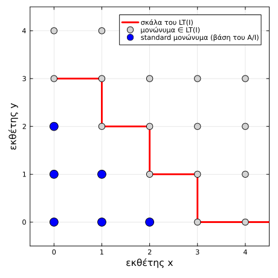

Η σκάλα του μεγιστοβάθμιου ιδεώδους $\mathrm{LT}(I)$ και τα standard μονώνυμα.

### 10.1.4 Ιδεώδη Απαλοιφής και το Θεώρημα Απαλοιφής

**ΣημείωσηΟρισμός (Ιδεώδες Απαλοιφής)**

Έστω $I \unlhd K[x_1,\dots,x_n]$. Το **$l$-οστό ιδεώδες απαλοιφής** είναι
$$I_l = I \cap K[x_{l+1}, \dots, x_n].$$

**ΣημαντικόΘεώρημα (Απαλοιφής)**

Έστω $G$ βάση Gröbner του $I$ ως προς τη lex διάταξη $x_1 > \cdots > x_n$. Τότε, για κάθε $0 \le l \le n-1$, το $G_l = G \cap K[x_{l+1},\dots,x_n]$ είναι βάση Gröbner του $I_l$.

Το θεώρημα αυτό είναι εξαιρετικά χρήσιμο: μας επιτρέπει να “απαλείφουμε” μεταβλητές από ένα σύστημα πολυωνυμικών εξισώσεων υπολογίζοντας απλώς μια βάση Gröbner ως προς τη lex διάταξη.

```julia
Ie = ideal(Ra, [xa^2 + ya^2 + za^2 - 1, xa^2 + 2ya^2 - 2, xa*za - 1])
eliminate(Ie, [xa])   # I_1 = I ∩ K[y,z]
```

```
Ideal generated by
  y^2 - z^2 - 1
  2*z^4 + 1
```

**ΣυμβουλήΆσκηση Cox, Little, και O’Shea (2007)**

Έστω $I = \langle x^2 + 2y^2 - 3, \, x^2 + xy + y^2 - 3 \rangle \subset \mathbb{C}[x,y]$.

(α) Βρείτε βάσεις των $I \cap \mathbb{C}[x]$ και $I \cap \mathbb{C}[y]$. (β) Βρείτε όλες τις λύσεις του συστήματος. (γ) Ποιες λύσεις είναι ρητές (στο $\mathbb{Q}^2$); (δ) Ποιο είναι το μικρότερο σώμα $k$ ώστε όλες οι λύσεις να βρίσκονται στο $k^2$;

Υπολογίζουμε πρώτα τα δύο ιδεώδη απαλοιφής, παραγοντοποιώντας τους γεννήτορές τους ώστε να δούμε τις πιθανές τιμές κάθε συντεταγμένης χωριστά:

```julia
Rexc, (xexc, yexc) = polynomial_ring(QQ, [:x, :y])
Iexc2 = ideal(Rexc, [xexc^2 + 2yexc^2 - 3, xexc^2 + xexc*yexc + yexc^2 - 3])
Ix, Iy = eliminate(Iexc2, [yexc]), eliminate(Iexc2, [xexc])
factor(gens(Ix)[1]), factor(gens(Iy)[1])
```

```
((x^2 - 3) * (x + 1) * (x - 1), (y - 1) * y * (y + 1))
```

Άρα $x \in \{1,-1,\sqrt{3},-\sqrt{3}\}$ και $y \in \{0,1,-1\}$ — όμως **όχι κάθε συνδυασμός** είναι πραγματική λύση του αρχικού συστήματος (το ιδεώδες απαλοιφής μόνο του δεν αρκεί, χρειάζεται και το Θεώρημα Επέκτασης για να ξέρουμε ποιοι συνδυασμοί επεκτείνονται). Ελέγχουμε άμεσα ποια ζεύγη ικανοποιούν και τις δύο αρχικές εξισώσεις:

```julia
real_solutions(Iexc2)[1]
```

```
4-element Vector{Vector{QQFieldElem}}:
 [63901395939770060407//36893488147419103232, 184351479614189213217957917//1569275433846670190958947355801916604025588861116008628224]
 [1, 1]
 [-1, -1]
 [-63901395939770060407//36893488147419103232, -184351479614189213217957917//1569275433846670190958947355801916604025588861116008628224]
```

Βλέπουμε λοιπόν $4$ λύσεις συνολικά, εκ των οποίων οι $(1,1)$ και $(-1,-1)$ είναι ρητές, ενώ οι άλλες δύο εμπλέκουν το $\sqrt{3}$ (μηδενική $y$-συντεταγμένη). Άρα το μικρότερο τέτοιο σώμα είναι το $k = \mathbb{Q}(\sqrt{3})$.

### 10.1.5 Τομή ιδεωδών

Για να υπολογίσουμε το $I \cap J$ ($I, J \unlhd K[x_1,\dots,x_n]$), εισάγουμε μια νέα μεταβλητή $t$ και θέτουμε
$$L = \langle t \cdot I, \ (1-t) \cdot J \rangle \subseteq K[t, x_1, \dots, x_n].$$
Τότε $I \cap J = L \cap K[x_1,\dots,x_n]$ — δηλαδή το ιδεώδες απαλοιφής του $L$ ως προς το $t$ (ο λόγος: αν $f \in L|_{t=0} \subseteq J$ και $f \in L|_{t=1} \subseteq I$, τότε $f$ ανεξάρτητο του $t$ βρίσκεται σε $I \cap J$· η αντίστροφη κατεύθυνση είναι άμεση).

```julia
Rt, (t, xt, yt) = polynomial_ring(QQ, [:t, :x, :y])
A, B = [xt^2 + yt], [xt - yt]
L = ideal(Rt, vcat([t*g for g in A], [(1 - t)*g for g in B]))
eliminate(L, [t])
```

```
Ideal generated by
  x^3 - x^2*y + x*y - y^2
```

```julia
R3, (x3, y3) = polynomial_ring(QQ, [:x, :y])
intersect(ideal(R3, [x3^2 + y3]), ideal(R3, [x3 - y3]))   # το OSCAR το κάνει απευθείας
```

```
Ideal generated by
  x^3 - x^2*y + x*y - y^2
```

## 10.2 Αφινικοί χώροι και αλγεβρικές ποικιλίες

Βλ. (Bandini, Gianni, και Sbarra 2024, τ. 159, κεφ. 3.1) (βλ. επίσης (Cox, Little, και O’Shea 2007, κεφ. 1, §2)).

**ΣημείωσηΟρισμός (Αφινικός χώρος, αλγεβρική ποικιλία)**

Ο **$n$-διάστατος αφινικός χώρος** πάνω από το $K$ είναι το σύνολο $K^n = \{(a_1,\dots,a_n) : a_i \in K\}$. Για $f_1,\dots,f_k \in K[x_1,\dots,x_n]$, το σύνολο
$$V(f_1,\dots,f_k) = \{ a \in K^n : f_i(a) = 0 \ \forall i \}$$
λέγεται **(αφινική) αλγεβρική ποικιλία**.

**Παραδείγματα.** Το $V(x^2+y^2-1) \subset \mathbb{R}^2$ είναι ο μοναδιαίος κύκλος. Το $V(x^2+y^2+1)$ είναι κενό πάνω από το $\mathbb{R}$, αλλά **μη κενό** πάνω από το $\mathbb{C}$ — η γεωμετρία μιας ποικιλίας εξαρτάται ουσιωδώς από το σώμα.

**ΣημαντικόΘεώρημα**

Αν $V, W \subseteq K^n$ είναι αλγεβρικές ποικιλίες, τότε και τα $V \cup W$, $V \cap W$ είναι αλγεβρικές ποικιλίες: αν $V = V(f_1,\dots,f_s)$ και $W = V(g_1,\dots,g_t)$, τότε
$$V \cap W = V(f_1,\dots,f_s,g_1,\dots,g_t), \qquad V \cup W = V(f_i g_j : 1 \le i \le s, \ 1 \le j \le t).$$

```julia
Rv, (xv, yv) = polynomial_ring(QQ, [:x, :y])
Iv = ideal(Rv, [xv^2 + yv^2 - 1])
Jv = ideal(Rv, [xv - yv])
IJunion = ideal(Rv, [f*g for f in gens(Iv) for g in gens(Jv)])
IJunion   # παράγει το V(Iv) ∪ V(Jv)
```

```
Ideal generated by
  x^3 - x^2*y + x*y^2 - x - y^3 + y
```

## 10.3 Θεώρημα Επέκτασης και Θεώρημα Κλειστότητας

Βλ. (Bandini, Gianni, και Sbarra 2024, τ. 159, κεφ. 3.3) (βλ. επίσης (Cox, Little, και O’Shea 2007, κεφ. 3, §1–2)).

Θεωρούμε την προβολή $\Pi_l : K^n \to K^{n-l}$, $\Pi_l(a_1,\dots,a_n) = (a_{l+1},\dots,a_n)$. Ένα φυσικό ερώτημα: πώς σχετίζεται το $V(I_l)$ (η ποικιλία του ιδεώδους απαλοιφής) με το $\Pi_l(V(I))$;

**ΣημαντικόΘεώρημα (Επέκτασης, Extension Theorem)**

Έστω $I = \langle f_1,\dots,f_s \rangle \subseteq \mathbb{C}[x_1,\dots,x_n]$, $I_1 = I \cap \mathbb{C}[x_2,\dots,x_n]$ το πρώτο ιδεώδες απαλοιφής, και γράφουμε $f_i = c_i(x_2,\dots,x_n) x_1^{N_i} + (\text{μικρότεροι όροι ως προς } x_1)$ με $c_i \not\equiv 0$. Αν $(a_2,\dots,a_n) \in V(I_1)$ **δεν** μηδενίζει όλα τα $c_i$, τότε επεκτείνεται σε λύση $(a_1,\dots,a_n) \in V(I)$.

**ΣημαντικόΘεώρημα (Κλειστότητας, Closure Theorem)**

Έστω $V = V(f_1,\dots,f_s) \subseteq \mathbb{C}^n$. Τότε το $V(I_1)$ είναι το **μικρότερο** αλγεβρικό σύνολο που περιέχει το $\Pi_1(V)$· επιπλέον, αν $V \neq \emptyset$, τότε $V(I_1) \setminus \Pi_1(V)$ περιέχεται σε γνήσιο αλγεβρικό υποσύνολο του $V(I_1)$ (δηλαδή το $\Pi_1(V)$ “γεμίζει” το $V(I_1)$ εκτός από ένα “μικρό” κομμάτι).

**Προειδοποίηση**

Το $\Pi_1(V)$ **δεν** είναι πάντα αλγεβρικό σύνολο — μόνο η κλειστότητά του, $V(I_1)$, είναι εγγυημένα. Κλασικό παράδειγμα: για $V = V(xy - 1) \subset \mathbb{C}^2$ (υπερβολή), $\Pi_1(V) = \mathbb{C}^* = \mathbb{C} \setminus \{0\}$ δεν είναι αλγεβρικό σύνολο, ενώ $V(I_1) = V(0) = \mathbb{C}$ (αφού το $1$ απαλείφεται εντελώς).

```julia
Rw, (xw, yw) = polynomial_ring(QQ, [:x, :y])
Iw = ideal(Rw, [xw*yw - 1])
eliminate(Iw, [xw])   # μηδενικό ιδεώδες: η προβολή στο y "γεμίζει" όλο το C, εκτός του y=0
```

```
Ideal generated by
  0
```

## 10.4 Περισσότερες εφαρμογές

Βλ. (Bandini, Gianni, και Sbarra 2024, τ. 159, κεφ. 3.5) (βλ. επίσης (Cox, Little, και O’Shea 2007, κεφ. 2, §8)).

### 10.4.1 Επίλυση αλγεβρικών συστημάτων

Για ένα **μηδενοδιάστατο** σύστημα (πεπερασμένο πλήθος λύσεων), η στρατηγική είναι: υπολογίζουμε μια βάση Gröbner ως προς τη lex διάταξη — από το Θεώρημα Απαλοιφής, αυτή μας δίνει ένα “τριγωνικό” σύστημα (όπως η απαλοιφή Gauss για γραμμικά συστήματα) που λύνεται διαδοχικά, ξεκινώντας από την τελευταία μεταβλητή.

```julia
Rs, (xs, ys) = polynomial_ring(QQ, [:x, :y])
Is = ideal(Rs, [xs + ys - 3, xs^2 + ys^2 - 5])
groebner_basis(Is, ordering = lex(Rs))
```

```
Gröbner basis with elements
  1: y^2 - 3*y + 2
  2: x + y - 3
with respect to the ordering
  lex([x, y])
```

```julia
real_solutions(Is)[1]
```

```
2-element Vector{Vector{QQFieldElem}}:
 [2, 1]
 [1, 2]
```

### 10.4.2 Προβολές ποικιλιών

Όπως είδαμε στο Θεώρημα Απαλοιφής/Επέκτασης, η προβολή $\Pi_l(V(I))$ **περιέχεται** πάντα στο $V(I_l)$, με ισότητα (έως ένα “μικρό” υποσύνολο) όταν εργαζόμαστε πάνω από αλγεβρικά κλειστό σώμα. Αυτό μετατρέπει το γεωμετρικό ερώτημα “ποια είναι η προβολή μιας ποικιλίας;” σε αλγεβριστικό υπολογισμό ενός ιδεώδους απαλοιφής — ακριβώς ό,τι κάναμε με την `eliminate` παραπάνω.

### 10.4.3 Αυτόματη απόδειξη γεωμετρικών θεωρημάτων

Η ίδια η ιδιότητα **ideal membership** μπορεί να αποδείξει θεωρήματα Ευκλείδειας γεωμετρίας: κωδικοποιούμε τις υποθέσεις ως πολυωνυμικές εξισώσεις $h_1 = \cdots = h_s = 0$ και το συμπέρασμα ως $g = 0$, και ελέγχουμε αν $g$ ανήκει στο (ριζικό του) ιδεώδους $\langle h_1,\dots,h_s \rangle$.

**Θεώρημα.** Οι διαγώνιοι ενός παραλληλογράμμου διχοτομούνται.

**Απόδειξη μέσω ιδεωδών.** Τοποθετούμε (χωρίς βλάβη της γενικότητας) $A=(0,0)$, $B=(b,0)$, και $C=(c_1,c_2)$, $D=(d_1,d_2)$ ελεύθερα. Οι υποθέσεις “$AB \parallel DC$” και “$AD \parallel BC$” (ορισμός παραλληλογράμμου) γράφονται
$$h_1 = c_2 - d_2, \qquad h_2 = d_1 c_2 - d_2(c_1 - b).$$
Το συμπέρασμα “τα μέσα των $AC$ και $BD$ ταυτίζονται” ισοδυναμεί (η μία συντεταγμένη είναι ήδη το $h_1$) με $g = c_1 - d_1 - b = 0$.

```julia
Rp, (b, c1, c2, d1, d2) = polynomial_ring(QQ, [:b, :c1, :c2, :d1, :d2])
h1 = c2 - d2
h2 = d1*c2 - d2*(c1 - b)
g = c1 - d1 - b
Ip = ideal(Rp, [h1, h2])
g in Ip
```

```
false
```

Το `g in Ip` βγαίνει `false`! Ελέγχοντας πιο προσεκτικά βλέπουμε γιατί: το $g$ ανήκει στο ιδεώδες μόνο **modulo** μια συνθήκη μη-εκφυλισμού:

```julia
c2 * g in Ip   # αλλά c2·g ανήκει στο ιδεώδες
```

```
true
```

Δηλαδή το συμπέρασμα ισχύει **εκτός αν** $c_2 = 0$ — δηλαδή εκτός αν τα $A, B, C$ είναι συνευθειακά (εκφυλισμένο “παραλληλόγραμμο”). Αυτό είναι χαρακτηριστικό παράδειγμα του πώς οι μέθοδοι αυτόματης απόδειξης θεωρημάτων συχνά χρειάζονται **συνθήκες μη-εκφυλισμού**, ακριβώς όπως συμβαίνει και στο Θεώρημα Επέκτασης.

**ΣυμβουλήΆσκηση**

Επαληθεύστε με το OSCAR ότι, αν προσθέσουμε την υπόθεση ότι το $ABCD$ είναι παραλληλόγραμμο **και** $AC \perp BD$ (ρόμβος), τότε $|AB| = |BC|$ (όλες οι πλευρές ίσες). Υπόδειξη: εκφράστε την καθετότητα ως $\langle C, D-B \rangle = 0$ (εσωτερικό γινόμενο) και ελέγξτε ideal membership όπως παραπάνω.

**ΠροσοχήΣύνοψη**

- Οι βάσεις Gröbner λύνουν αλγοριθμικά: το ideal membership, την ισότητα ιδεωδών, και τον υπολογισμό της διάστασης του $A/I$ ως $K$-διανυσματικού χώρου.
- **Ιδεώδη απαλοιφής**: μια βάση Gröbner ως προς διάταξη απαλοιφής (π.χ. lex) δίνει απευθείας γεννήτορες του ιδεώδους απαλοιφής.
- Τα Θεωρήματα **Επέκτασης** και **Κλειστότητας** συνδέουν το ιδεώδες απαλοιφής με την προβολή της ποικιλίας — με τις αναγκαίες προειδοποιήσεις (π.χ. ρίζες στο άπειρο, μη αλγεβρικές προβολές).
- Οι βάσεις Gröbner λύνουν επίσης αλγεβρικά συστήματα (μέσω lex και `real_solutions`), υπολογίζουν προβολές ποικιλιών, και αποδεικνύουν αυτόματα γεωμετρικά θεωρήματα μέσω ideal membership.

# 11 Πολυπλοκότητα και Κρυπτογραφία

## 11.1 Πολυπλοκότητα υπολογισμού βάσεων Gröbner

Έχουμε δει ότι ο αλγόριθμος του Buchberger πάντα τερματίζει (μέσω του Θεωρήματος Βάσης Hilbert / ACC), αλλά δεν έχουμε πει τίποτα για το **πόσο** χρόνο ή χώρο χρειάζεται. Η ερώτηση είναι εξ ίσου φυσική για τον προγραμματιστή όσο και για τον θεωρητικό: πόσο μεγάλοι μπορεί να γίνουν οι συντελεστές και οι βαθμοί των πολυωνύμων μιας βάσης Gröbner, συναρτήσει του αριθμού των μεταβλητών $n$ και του βαθμού $d$ των αρχικών γεννητόρων;

**ΣημαντικόΘεώρημα (Φράγμα του Dubé) (Dubé 1990)**

Έστω $I = \langle f_1,\dots,f_s \rangle \unlhd K[x_1,\dots,x_n]$ με $\deg(f_i) \le d$ για κάθε $i$. Τότε, για **κάθε** διάταξη όρων, η ανηγμένη βάση Gröbner του $I$ αποτελείται από πολυώνυμα βαθμού το πολύ
$$D(n,d) \;\le\; 2\left(\frac{d^2}{2}+d\right)^{2^{n-1}}.$$

Το φράγμα αυτό είναι **διπλά εκθετικό** ως προς $n$ — δραματικά χειρότερο από, π.χ., το φράγμα Bézout $d^n$ για τον αριθμό των λύσεων ενός μηδενοδιάστατου συστήματος. Θα μπορούσε κανείς να ελπίζει ότι πρόκειται απλώς για αδυναμία του συγκεκριμένου αλγορίθμου (Buchberger) ή της συγκεκριμένης απόδειξης· δυστυχώς δεν είναι έτσι:

**ΣημαντικόΘεώρημα (Mayr–Meyer, 1982) (Mayr και Meyer 1982)**

Υπάρχει οικογένεια ιδεωδών $I_n \unlhd K[x_1,\dots,x_{cn}]$ (για κατάλληλη σταθερά $c$), παραγόμενων από πολυώνυμα σταθερού (μικρού) βαθμού, τέτοια ώστε **κάθε** βάση Gröbner του $I_n$ — ως προς **οποιαδήποτε** διάταξη όρων — να περιέχει στοιχείο βαθμού διπλά εκθετικού ως προς $n$. Συνακόλουθα, το πρόβλημα του **ideal membership** (και το αντίστοιχο word problem για μεταθετικά μονοειδή) είναι EXPSPACE-hard.

Δηλαδή το διπλά εκθετικό φράγμα δεν είναι τεχνικό ελάττωμα του αλγορίθμου του Buchberger — είναι **εγγενές** στο πρόβλημα: καμία μέθοδος (Gröbner ή όχι) δεν μπορεί να λύνει το ideal membership problem σε γενικότητα με λιγότερους πόρους, στη χειρότερη περίπτωση. Αυτό εξηγεί γιατί συστήματα λογισμικού όπως το OSCAR/Singular/Macaulay2, παρ’ όλη την εκπληκτική τους πρακτική αποδοτικότητα, μπορούν σε συγκεκριμένα (τεχνητά κατασκευασμένα) παραδείγματα να “κολλήσουν” εντελώς.

Η εικόνα δεν είναι τόσο απαισιόδοξη στην πράξη, για δύο λόγους:

1. **Η διάταξη όρων έχει τεράστια σημασία.** Η lex διάταξη τείνει να παράγει τις μεγαλύτερες βάσεις (γι’ αυτό και τη χρησιμοποιούμε κυρίως για την πληροφορία της απαλοιφής που μας δίνει, όχι για ταχύτητα), ενώ η `degrevlex` είναι εμπειρικά η πιο αποδοτική επιλογή γενικού σκοπού. Στην πράξη υπολογίζουμε πρώτα μια βάση ως προς `degrevlex` και, αν χρειαζόμαστε lex (π.χ. για επίλυση μηδενοδιάστατου συστήματος όπως στην §Επίλυση αλγεβρικών συστημάτων), αλλάζουμε διάταξη με τον αλγόριθμο **FGLM** (Faugère κ.ά. 1993) — ο οποίος, για μηδενοδιάστατο ιδεώδες με $\dim_K (A/I) = D$, κάνει την αλλαγή σε $O(nD^3)$ πράξεις πεδίου, χωρίς να επαναλάβει τον Buchberger εξ αρχής. (Ο αλγόριθμος αυτός οφείλεται εν μέρει στην Patrizia Gianni, συγγραφέα του κύριου βιβλίου αναφοράς του μαθήματος.)
2. **Οι “παθολογικές” περιπτώσεις είναι σπάνιες.** Για “γενικά” ιδεώδη (π.χ. τυχαίους/γενικούς γεννήτορες) τα φράγματα σχετίζονται με τη **κανονικότητα Castelnuovo–Mumford** και είναι πολύ πιο ήπια — απλά εκθετικά ή και πολυωνυμικά για σταθερό $n$ (Bayer και Mumford 1993). Αλγόριθμοι όπως οι **F4/F5** του Faugère (Faugère 1999) εκμεταλλεύονται αυτό μετατρέποντας τον υπολογισμό βάσης Gröbner σε αραιή γραμμική άλγεβρα (απαλοιφή Gauss σε πίνακες Macaulay), αποφεύγοντας συστηματικά τους S-πολυωνυμικούς υπολογισμούς που ανάγονται σε μηδέν.

**ΣυμβουλήΆσκηση**

Υπολογίστε στο OSCAR τη βάση Gröbner του ίδιου ιδεώδους ως προς `lex` και ως προς `degrevlex`, για ένα μη τετριμμένο παράδειγμα με $\ge 4$ μεταβλητές (π.χ. το κλασικό ιδεώδες Katsura ή ένα κυκλικό σύστημα `cyclic(n)`). Συγκρίνετε το πλήθος και τους μέγιστους βαθμούς των γεννητόρων στις δύο βάσεις.

## 11.2 Εφαρμογές στην Κρυπτογραφία και τη Θεωρία Κωδίκων

### 11.2.1 Πολυμεταβλητή κρυπτογραφία και αλγεβρική κρυπτανάλυση

Πολλά σύγχρονα κρυπτοσυστήματα δημοσίου κλειδιού (ιδίως υποψήφια για **μετα-κβαντική κρυπτογραφία**, όπως τα Rainbow, GeMSS, HFE) βασίζουν την ασφάλειά τους στη δυσκολία του προβλήματος:

> **MQ (Multivariate Quadratic):** δοθέντος συστήματος $f_1(\mathbf{x})=\cdots=f_m(\mathbf{x})=0$ τετραγωνικών πολυωνύμων πάνω από πεπερασμένο σώμα $\mathbb{F}_q$, βρείτε $\mathbf{x} \in \mathbb{F}_q^n$ που το ικανοποιεί.

Το πρόβλημα αυτό είναι NP-hard γενικά, αλλά το δημόσιο κλειδί κάθε τέτοιου σχήματος **είναι** ένα τέτοιο σύστημα (κατασκευασμένο ώστε να κρύβει μια “εύκολη” δομή, γνωστή μόνο στον κάτοχο του ιδιωτικού κλειδιού). Η **αλγεβρική κρυπτανάλυση** μοντελοποιεί την ανάκτηση του κλειδιού (ή απλά την πλαστογράφηση μιας υπογραφής) ως ακριβώς αυτό το πρόβλημα: υπολογίζουμε μια βάση Gröbner του ιδεώδους $\langle f_1,\dots,f_m \rangle$ (συνήθως πάνω από $\mathbb{F}_2$, με τις σχεσιακές εξισώσεις πεδίου $x_i^2 - x_i$ προστιθέμενες για να περιορίσουμε τις λύσεις στο $\{0,1\}^n$) και διαβάζουμε τις ρίζες από μια βάση ως προς `lex` (ή μέσω FGLM, βλ. παραπάνω). Αλγόριθμοι όπως ο **XL** και οι **F4/F5** είναι τα βασικά εργαλεία τέτοιων επιθέσεων· η ασφάλεια ενός σχήματος MQ αξιολογείται ουσιαστικά εκτιμώντας το πραγματικό (πρακτικό) κόστος αυτού του υπολογισμού βάσης Gröbner, χρησιμοποιώντας ακριβώς τα φράγματα κανονικότητας που αναφέραμε παραπάνω (Bard 2009). Ιστορικά, αρκετά σχήματα (π.χ. πρώιμες παραμετροποιήσεις του HFE) “έσπασαν” επειδή το αντίστοιχο σύστημα αποδείχθηκε λιγότερο “γενικό” απ’ ό,τι υποτίθεται, με αποτέλεσμα η βάση Gröbner του να υπολογίζεται πολύ πιο γρήγορα απ’ το αναμενόμενο.

### 11.2.2 Θεωρία κωδίκων: αποκωδικοποίηση ως ideal membership

Στην κατεύθυνση της θεωρίας κωδίκων, πολλά προβλήματα αποκωδικοποίησης αλγεβρικών κωδίκων (π.χ. κώδικες Reed–Solomon, κώδικες Reed–Muller, κώδικες αλγεβρικής γεωμετρίας) ανάγονται σε ερωτήματα για το **ιδεώδες εξαφάνισης** (vanishing ideal) ενός πεπερασμένου συνόλου σημείων — ακριβώς η δομή που είδαμε στο Θεώρημα για την πεπερασμένη διάσταση του $A/I$ (§[Ο δακτύλιος πηλίκο]). Συγκεκριμένα: ένας κώδικας αξιολόγησης (evaluation code) ορίζεται εκτιμώντας πολυώνυμα σε ένα σύνολο σημείων $X = \{P_1,\dots,P_m\} \subseteq \mathbb{F}_q^n$, και οι ιδιότητές του (απόσταση, διορθωτική ικανότητα) καθορίζονται από τη δομή του ιδεώδους $I(X)$ και της βάσης Gröbner του. Ο αλγόριθμος **Buchberger–Möller** υπολογίζει ακριβώς μια βάση Gröbner του $I(X)$ απευθείας από τα σημεία (χωρίς να περάσει από γεννήτορες), και είναι το βασικό εργαλείο τόσο για την κατασκευή τέτοιων κωδίκων όσο και για την αποκωδικοποίησή τους μέσω ελέγχων ideal membership στο ιδεώδες σφάλματος (Gathen και Gerhard 2013).

**ΣυμβουλήΆσκηση**

Κατασκευάστε στο OSCAR ένα τοξ-παράδειγμα MQ συστήματος πάνω από $\mathbb{F}_2$ με $n=6$ μεταβλητές (τυχαία τετραγωνικά πολυώνυμα, συν τις εξισώσεις πεδίου $x_i^2-x_i$) με μία γνωστή ρίζα $\mathbf{a} \in \{0,1\}^6$. Επαληθεύστε ότι η βάση Gröbner ως προς `lex` σας επιτρέπει να ανακτήσετε το $\mathbf{a}$, και μετρήστε πώς μεταβάλλεται ο χρόνος υπολογισμού καθώς αυξάνετε το $n$.

**ΠροσοχήΣύνοψη**

- Ο βαθμός μιας βάσης Gröbner μπορεί να είναι **διπλά εκθετικός** ως προς τον αριθμό μεταβλητών (φράγμα Dubé) — και αυτό είναι αναπόφευκτο σε γενικότητα (Mayr–Meyer), όχι απλώς αδυναμία του αλγορίθμου Buchberger.
- Στην πράξη, η επιλογή διάταξης όρων (degrevlex αντί lex) και αλγόριθμοι όπως οι F4/F5 κάνουν τεράστια πρακτική διαφορά.
- Οι βάσεις Gröbner έχουν άμεσες εφαρμογές στην **αλγεβρική κρυπτανάλυση** (πολυμεταβλητή κρυπτογραφία, πρόβλημα MQ) και στην **αποκωδικοποίηση** αλγεβρικών κωδίκων.

# 12 Θέματα Εργασιών Εξαμήνου

## 12.1 Θέματα εργασιών εξαμήνου

Οι παρακάτω θεματικές είναι κατάλληλες για ατομική ή ομαδική εργασία εξαμήνου: κάθε μία επεκτείνει άμεσα υλικό του μαθήματος, έχει σαφή υπολογιστική συνιστώσα υλοποιήσιμη στο OSCAR, και οδηγεί σε πλούσια βιβλιογραφία για περαιτέρω μελέτη.

**Πολυωνυμική παραγοντοποίηση — πέρα από τα βασικά.** Είδαμε ήδη στην §Παραγοντοποίηση πολυωνύμων τα Berlekamp, Cantor–Zassenhaus, ανύψωση Hensel και LLL. Μια εργασία θα μπορούσε να προχωρήσει σε πρακτική σύγκριση απόδοσης (μέγεθος εισόδου έναντι χρόνου) των μεθόδων, ή στην παραγοντοποίηση **πολλών μεταβλητών** (η οποία ανάγεται στη μονομεταβλητή περίπτωση μέσω ανύψωσης Hensel σε πολλές μεταβλητές). Σύνδεση με το μάθημα: η παραγοντοποίηση χρησιμοποιείται συχνά ως προεπεξεργασία πριν τον υπολογισμό βάσης Gröbner, για να απλοποιήσει τους γεννήτορες ενός ιδεώδους. Αναφορά: (Gathen και Gerhard 2013, κεφ. 14–16).

**Συμβολική ολοκλήρωση (αλγόριθμος Risch).** Πώς αποφασίζει ένα CAS αν μια στοιχειώδης συνάρτηση έχει στοιχειώδες αντιπαράγωγο, και πώς το υπολογίζει όταν υπάρχει (π.χ. γιατί το $\int e^{x^2}dx$ δεν έχει κλειστή μορφή, ενώ το $\int x e^{x^2}dx$ έχει); Θέματα προς διερεύνηση: η δομή των διαφορικών σωμάτων (differential fields) και το θεώρημα του Liouville, ο αλγόριθμος Risch για ρητές/εκθετικές/λογαριθμικές συναρτήσεις, και γιατί ο πλήρης αλγόριθμος Risch θεωρείται ένας από τους πιο πολύπλοκους αλγορίθμους που έχουν υλοποιηθεί σε CAS. Σύνδεση με το μάθημα: διαφορετικό υπολογιστικό υπόβαθρο (διαφορική άλγεβρα αντί για μεταθετική άλγεβρα/ιδεώδη), αλλά ίδιο πνεύμα — αλγοριθμική απόφανση για συμβολικά αντικείμενα.

**Τορικά ιδεώδη.** Ένα τορικό ιδεώδες είναι το ιδεώδες εξαφάνισης μιας παραμετρικής (μονωνυμικής) απεικόνισης $t \mapsto (t^{a_1},\dots,t^{a_n})$, και συνδέει τη μεταθετική άλγεβρα με τη συνδυαστική (πολύτοπα, πλέγματα). Θέματα προς διερεύνηση: υπολογισμός τορικού ιδεώδους μέσω απαλοιφής (ακριβώς η τεχνική του Θεωρήματος Απαλοιφής που είδαμε), η σύνδεση βάσεων Gröbner τορικών ιδεωδών με τριγωνοποιήσεις πολυτόπων, και εφαρμογές σε ακέραιο προγραμματισμό / στατιστική. Αναφορά: (Sturmfels 1996).

**Αραιή απαλοιφή (sparse elimination).** Είδαμε ήδη στο §Αραιά συστήματα και το Θεώρημα BKK τα βασικά (πολύτοπα Newton, μεικτός όγκος, θεώρημα BKK)· μια εργασία θα μπορούσε να προχωρήσει στην **αραιή απαλοίφουσα** (sparse resultant) ως γενίκευση της απαλοίφουσας Sylvester/Macaulay, και σε αλγορίθμους υπολογισμού της μέσω πολυτόπων Newton. Σύνδεση με το μάθημα: άμεση επέκταση της §Απαλοίφουσα (Resultant). Αναφορά: (Cox, Little, και O’Shea 2005, τ. 185, κεφ. 7).

**Αλγεβρικός σχεδιασμός κίνησης (Algebraic Motion Planning).** Πώς γενικεύεται το παράδειγμα του ρομποτικού βραχίονα (§Μοντελοποίηση προβλημάτων με πολυωνυμικά συστήματα) σε ρομπότ με περισσότερους βαθμούς ελευθερίας, ή με εμπόδια στο χώρο εργασίας; Θέματα προς διερεύνηση: αναπαράσταση του χώρου διαμορφώσεων (configuration space) ως αλγεβρική ποικιλία, και χρήση Gröbner bases / CAD (cylindrical algebraic decomposition) για τον προσδιορισμό εφικτών διαδρομών.

**Απομόνωση ριζών με συνεχή κλάσματα — πέρα από τα βασικά.** Είδαμε ήδη στην §Απομόνωση ριζών με συνεχή κλάσματα τον αλγόριθμο cf και τη βασική του πολυπλοκότητα (Τσιγαρίδας 2006). Μια εργασία θα μπορούσε να υλοποιήσει τη βελτιωμένη εκδοχή του Akritas (μετάθεση κατά το κάτω φράγμα αντί κατά μονάδα, βλ. Θεώρ. 3.46–3.47 της διατριβής), να μετρήσει πειραματικά το πραγματικό βάθος του δέντρου έναντι της υποδιαίρεσης/Sturm, ή να διερευνήσει τη σύνδεση των αναγωγημάτων με την κατανομή Gauss–Kuzmin.

**Συστολικοί αλγόριθμοι σε FPGA.** Υλοποίηση θεμελιωδών αλγορίθμων υπολογιστικής άλγεβρας (π.χ. Ευκλείδειος αλγόριθμος, αναγωγή, ή τμήματα του Buchberger) ως συστολικά κυκλώματα σε FPGA, με στόχο την επιτάχυνση μέσω παραλληλισμού υλικού. Θέματα προς διερεύνηση: σχεδιασμός συστολικού πίνακα για πολυωνυμικό πολλαπλασιασμό/αναγωγή, και πειραματική σύγκριση απόδοσης με λογισμικό.

**Ακέραιος γραμμικός προγραμματισμός μέσω βάσεων Gröbner.** Ο αλγόριθμος Conti–Traverso λύνει προβλήματα ακέραιου προγραμματισμού (IP) ανάγοντάς τα σε υπολογισμό βάσης Gröbner ενός τορικού ιδεώδους: οι εφικτές ακέραιες λύσεις κωδικοποιούνται ως μονώνυμα, και η ελάχιστη λύση ως προς έναν στόχο προκύπτει ανάγοντας ένα κατάλληλο μονώνυμο ως προς την ανηγμένη βάση Gröbner. Θέματα προς διερεύνηση: η κατασκευή του τορικού ιδεώδους από τους περιορισμούς του IP, η επιλογή διάταξης όρων συμβατής με τη συνάρτηση κόστους, και πειραματική σύγκριση με κλασικές μεθόδους (simplex/branch-and-bound) σε μικρά στιγμιότυπα. Σύνδεση με το μάθημα: συνδυάζει την §Ο αλγόριθμος του Buchberger με το προηγούμενο θέμα των τορικών ιδεωδών. Αναφορά: (Conti και Traverso 1991) (βλ. επίσης (Sturmfels 1996, τ. 8, κεφ. 5)).

**Το φράγμα διαχωρισμού DMM.** Μια εργασία θα μπορούσε να μελετήσει το φράγμα διαχωρισμού DMM, συγκρίνοντάς το με το φράγμα Mignotte που είδαμε στην §Φράγμα διαχωρισμού και πολυπλοκότητα της υποδιαίρεσης, τόσο θεωρητικά όσο και πειραματικά (π.χ. πόσο επηρεάζει στην πράξη το βάθος του δέντρου υποδιαίρεσης στον αλγόριθμο απομόνωσης ριζών).

*(Άλλα θέματα — π.χ. modular/multi-modular υπολογισμός βάσεων Gröbner, ή αριθμητική αλγεβρική γεωμετρία μέσω homotopy continuation — μπορούν να προταθούν κατόπιν συνεννόησης.)*

**ΠροσοχήΣύνοψη**

- Το μάθημα κάλυψε: βασικές αλγεβρικές δομές, παραγοντοποίηση πολυωνύμων, απομόνωση πραγματικών ριζών, θεωρία ιδεωδών, βάσεις Gröbner (θεωρία, αλγόριθμος, εφαρμογές), απαλοίφουσες, πολυπλοκότητα και εφαρμογές.
- Οι θεματικές αυτού του κεφαλαίου επεκτείνουν άμεσα υλικό του μαθήματος προς νέες κατευθύνσεις — τορικά ιδεώδη, αραιή απαλοιφή, ακέραιος γραμμικός προγραμματισμός, συμβολική ολοκλήρωση, modular γραμμική άλγεβρα, και άλλα.

## Αναφορές

Adams, William W., και Philippe Loustaunau. 1994. *An Introduction to Gröbner Bases*. Τ. 3. Graduate Studies in Mathematics. Providence, RI: American Mathematical Society.

Bandini, Andrea, Patrizia Gianni, και Enrico Sbarra. 2024. *Commutative Algebra through Exercises*. Τ. 159. UNITEXT. Cham: Springer Nature Switzerland. https://doi.org/10.1007/978-3-031-56910-4.

Bard, Gregory V. 2009. *Algebraic Cryptanalysis*. New York: Springer. https://doi.org/10.1007/978-0-387-88757-9.

Bayer, Dave, και David Mumford. 1993. ‘What Can Be Computed in Algebraic Geometry?’ Στο *Computational Algebraic Geometry and Commutative Algebra (Cortona, 1991)*, XXXIV:1–48. Symposia Mathematica. Cambridge University Press.

Berlekamp, Elwyn R. 1967. ‘Factoring Polynomials Over Finite Fields’. *Bell System Technical Journal* 46 (8): 1853–59. https://doi.org/10.1002/j.1538-7305.1967.tb03174.x.

Cantor, David G., και Hans Zassenhaus. 1981. ‘A New Algorithm for Factoring Polynomials over Finite Fields’. *Mathematics of Computation* 36 (154): 587–92. https://doi.org/10.1090/S0025-5718-1981-0606517-5.

Conti, Pasqualina, και Carlo Traverso. 1991. ‘Buchberger Algorithm and Integer Programming’. Στο *Applied Algebra, Algebraic Algorithms and Error-Correcting Codes (AAECC-9)*, 539:130–39. Lecture Notes in Computer Science. Springer. https://doi.org/10.1007/3-540-54522-0_102.

Cox, David A., John Little, και Donal O’Shea. 2005. *Using Algebraic Geometry*. 2ο έκδ. Τ. 185. Graduate Texts in Mathematics. New York: Springer.

———. 2007. *Ideals, Varieties, and Algorithms: An Introduction to Computational Algebraic Geometry and Commutative Algebra*. 3ο έκδ. Undergraduate Texts in Mathematics. New York: Springer.

Dubé, Thomas W. 1990. ‘The Structure of Polynomial Ideals and Gröbner Bases’. *SIAM Journal on Computing* 19 (4): 750–73. https://doi.org/10.1137/0219053.

Faugère, Jean-Charles. 1999. ‘A new efficient algorithm for computing Gröbner bases (F4)’. *Journal of Pure and Applied Algebra* 139 (1–3): 61–88. https://doi.org/10.1016/S0022-4049(99)00005-5.

Faugère, Jean-Charles, Patrizia Gianni, Daniel Lazard, και Teo Mora. 1993. ‘Efficient Computation of Zero-dimensional Gröbner Bases by Change of Ordering’. *Journal of Symbolic Computation* 16 (4): 329–44. https://doi.org/10.1006/jsco.1993.1051.

Gathen, Joachim von zur, και Jürgen Gerhard. 2013. *Modern Computer Algebra*. 3ο έκδ. Cambridge University Press.

Lenstra, A. K., H. W. Lenstra, και L. Lovász. 1982. ‘Factoring Polynomials with Rational Coefficients’. *Mathematische Annalen* 261: 515–34. https://doi.org/10.1007/BF01457454.

Mayr, Ernst W., και Albert R. Meyer. 1982. ‘The complexity of the word problems for commutative semigroups and polynomial ideals’. *Advances in Mathematics* 46 (3): 305–29. https://doi.org/10.1016/0001-8708(82)90048-2.

Sturmfels, Bernd. 1996. *Gröbner Bases and Convex Polytopes*. Τ. 8. University Lecture Series. Providence, RI: American Mathematical Society.

Waerden, B. L. van der. 1950. *Modern Algebra*. Τ. 2. New York: Frederick Ungar Publishing Co.

Τσιγαρίδας, Ηλίας Π. 2006. ‘Αλγεβρικοί αλγόριθμοι και εφαρμογές στη γεωμετρία’. Phdthesis, Αθήνα: Εθνικό και Καποδιστριακό Πανεπιστήμιο Αθηνών, Τμήμα Πληροφορικής και Τηλεπικοινωνιών.